# wrangle_act

```python
#Loading needed packages
import pandas as pd
import numpy as np
import requests
import tweepy
import json
import re
import matplotlib.pyplot as plt
import seaborn as sns

# to make sure all visualizations are plotted inline with the notebook
%matplotlib inline
```

```python
#setting the width of the columns so i can see all contents

pd.set_option('display.max_colwidth', -1)
```

## Gathering The Data:

I am gathering the data from 3 sources:

1. Manually downloading an existing file: **twitter-archive-enhanced.csv**
2. Programmatically downloading a file from the internet: **image-predictions.tsv**
3. Using API to gather and download data: **tweet_json.txt**

```python
#downloading the file from the URL
url = 'https://d17h27t6h515a5.cloudfront.net/topher/2017/August/599fd2ad_image-predictions/image-predictions.tsv'
r = requests.get(url)
```

```python
#saving the response in a tsv file
with open(url.split('/')[-1], mode='wb') as file:
    file.write(r.content)
```

```python
#Connecting to Twitter API
import tweepy

consumer_key = '*************************'
consumer_secret = '*************************'
access_token = '*************************'
access_secret = '*************************'

auth = tweepy.OAuthHandler(consumer_key, consumer_secret)
auth.set_access_token(access_token, access_secret)

api = tweepy.API(auth, wait_on_rate_limit = True, wait_on_rate_limit_notify = True)
```

```python
#downloading JSON file

tweets_id = tweets['tweet_id']
error_id = []
with open ('tweet_json.txt', mode='w+') as file:
    for t_id in tweets_id:

        try:
            status = api.get_status(t_id, tweet_mode='extended')
            json_str = json.dumps(status._json)

        except Exception as e:
            error_id.append(t_id)

            continue

        file.write(json_str + '\n')
```

```
Rate limit reached. Sleeping for: 725
Rate limit reached. Sleeping for: 725
```

```python
#reading JSON file
t_id = []
fave_count = []
rtweet_count = []
timestamp = []
with open('tweet_json.txt', mode = 'r') as f:
     for line in f.readlines():
            data = json.loads(line)
            t_id.append(data['id'])
            fave_count.append(data['favorite_count'])
            rtweet_count.append(data['retweet_count'])
            timestamp.append(data['created_at'])

json_tweets = pd.DataFrame({'tweet_id':t_id,
                            'favorite_count':fave_count,
                            'retweet_count':rtweet_count,
                            'timestamp': pd.to_datetime(timestamp)})
```

```python
#reading file
images = pd.read_csv('image-predictions.tsv', sep ='\t')
```

```python
#reading file
tweets = pd.read_csv('twitter-archive-enhanced.csv')
```

## Assessing The Data:

Intensive visual assessment were done throughout the Assessment process using Excel

```python
#Checking the datatype of the first dataset variables
tweets.info()
```

```
<class 'pandas.core.frame.DataFrame'>
RangeIndex: 2356 entries, 0 to 2355
Data columns (total 17 columns):
tweet_id                      2356 non-null int64
in_reply_to_status_id         78 non-null float64
in_reply_to_user_id           78 non-null float64
timestamp                     2356 non-null object
source                        2356 non-null object
text                          2356 non-null object
retweeted_status_id           181 non-null float64
retweeted_status_user_id      181 non-null float64
retweeted_status_timestamp    181 non-null object
expanded_urls                 2297 non-null object
rating_numerator              2356 non-null int64
rating_denominator            2356 non-null int64
name                          2356 non-null object
doggo                         2356 non-null object
floofer                       2356 non-null object
pupper                        2356 non-null object
puppo                         2356 non-null object
dtypes: float64(4), int64(3), object(10)
memory usage: 313.0+ KB
```

```python
#Let's see some samples, i would like to know how the values in the columns look like

tweets.sample(5)
```

|  | tweet_id | in_reply_to_status_id | in_reply_to_user_id | timestamp | source | text | retweeted_status_id | retweeted_status_user_id | retweeted_status_timestamp | expanded_urls | rating_numerator | rating_denominator | name | doggo | floofer | pupper | puppo |
| --- | --- | --- | --- | --- | --- | --- | --- | --- | --- | --- | --- | --- | --- | --- | --- | --- | --- |
| 15 | 889278841981685760 | NaN | NaN | 2017-07-24 00:19:32 +0000 | <a href="http://twitter.com/download/iphone" rel="nofollow">Twitter for iPhone</a> | This is Oliver. You're witnessing one of his many brutal attacks. Seems to be playing with his victim. 13/10 fr*ckin frightening #BarkWeek https://t.co/WpHvrQedPb | NaN | NaN | NaN | https://twitter.com/dog_rates/status/889278841981685760/video/1 | 13 | 10 | Oliver | None | None | None | None |
| 197 | 854482394044301312 | NaN | NaN | 2017-04-18 23:50:52 +0000 | <a href="http://twitter.com/download/iphone" rel="nofollow">Twitter for iPhone</a> | This is Arya. She can barely contain her excitement for more peanut butter. Also patriotic af. 13/10 https://t.co/AL4Ahm1Rm5 | NaN | NaN | NaN | https://twitter.com/dog_rates/status/854482394044301312/photo/1 | 13 | 10 | Arya | None | None | None | None |
| 1649 | 683742671509258241 | NaN | NaN | 2016-01-03 20:12:10 +0000 | <a href="http://twitter.com/download/iphone" rel="nofollow">Twitter for iPhone</a> | Meet Sebastian. He's a womanizer. Romantic af. Always covered in flower petals. Also a poet. 11/10 dreamy as hell https://t.co/eoL1bCpWCg | NaN | NaN | NaN | https://twitter.com/dog_rates/status/683742671509258241/photo/1 | 11 | 10 | Sebastian | None | None | None | None |
| 1321 | 706310011488698368 | NaN | NaN | 2016-03-06 02:46:44 +0000 | <a href="http://twitter.com/download/iphone" rel="nofollow">Twitter for iPhone</a> | Here's a very sleepy pupper. Thinks it's an airplane. 12/10 would snug for eternity https://t.co/GGmcTIkBbf | NaN | NaN | NaN | https://twitter.com/dog_rates/status/706310011488698368/photo/1,https://twitter.com/dog_rates/status/706310011488698368/photo/1 | 12 | 10 | None | None | None | pupper | None |
| 2101 | 670691627984359425 | NaN | NaN | 2015-11-28 19:51:59 +0000 | <a href="http://twitter.com/download/iphone" rel="nofollow">Twitter for iPhone</a> | This is Ester. He has a cocaine problem. This is an intervention Ester. We all care about you. 8/10 https://t.co/eCVj2xT59V | NaN | NaN | NaN | https://twitter.com/dog_rates/status/670691627984359425/photo/1 | 8 | 10 | Ester | None | None | None | None |

```python
#the notnull values are the retweet, this i don't need in my master dataset

tweets[tweets.retweeted_status_id.notnull()]
```

|  | tweet_id | in_reply_to_status_id | in_reply_to_user_id | timestamp | source | text | retweeted_status_id | retweeted_status_user_id | retweeted_status_timestamp | expanded_urls | rating_numerator | rating_denominator | name | doggo | floofer | pupper | puppo |
| --- | --- | --- | --- | --- | --- | --- | --- | --- | --- | --- | --- | --- | --- | --- | --- | --- | --- |
| 19 | 888202515573088257 | NaN | NaN | 2017-07-21 01:02:36 +0000 | <a href="http://twitter.com/download/iphone" rel="nofollow">Twitter for iPhone</a> | RT @dog_rates: This is Canela. She attempted some fancy porch pics. They were unsuccessful. 13/10 someone help her https://t.co/cLyzpcUcMX | 8.874740e+17 | 4.196984e+09 | 2017-07-19 00:47:34 +0000 | https://twitter.com/dog_rates/status/887473957103951883/photo/1,https://twitter.com/dog_rates/status/887473957103951883/photo/1,https://twitter.com/dog_rates/status/887473957103951883/photo/1,https://… | 13 | 10 | Canela | None | None | None | None |
| 32 | 886054160059072513 | NaN | NaN | 2017-07-15 02:45:48 +0000 | <a href="http://twitter.com/download/iphone" rel="nofollow">Twitter for iPhone</a> | RT @Athletics: 12/10 #BATP https://t.co/WxwJmvjfxo | 8.860537e+17 | 1.960740e+07 | 2017-07-15 02:44:07 +0000 | https://twitter.com/dog_rates/status/886053434075471873,https://twitter.com/dog_rates/status/886053434075471873 | 12 | 10 | None | None | None | None | None |
| 36 | 885311592912609280 | NaN | NaN | 2017-07-13 01:35:06 +0000 | <a href="http://twitter.com/download/iphone" rel="nofollow">Twitter for iPhone</a> | RT @dog_rates: This is Lilly. She just parallel barked. Kindly requests a reward now. 13/10 would pet so well https://t.co/SATN4If5H5 | 8.305833e+17 | 4.196984e+09 | 2017-02-12 01:04:29 +0000 | https://twitter.com/dog_rates/status/830583320585068544/photo/1,https://twitter.com/dog_rates/status/830583320585068544/photo/1,https://twitter.com/dog_rates/status/830583320585068544/photo/1,https://… | 13 | 10 | Lilly | None | None | None | None |
| 68 | 879130579576475649 | NaN | NaN | 2017-06-26 00:13:58 +0000 | <a href="http://twitter.com/download/iphone" rel="nofollow">Twitter for iPhone</a> | RT @dog_rates: This is Emmy. She was adopted today. Massive round of pupplause for Emmy and her new family. 14/10 for all involved https://… | 8.780576e+17 | 4.196984e+09 | 2017-06-23 01:10:23 +0000 | https://twitter.com/dog_rates/status/878057613040115712/photo/1,https://twitter.com/dog_rates/status/878057613040115712/photo/1 | 14 | 10 | Emmy | None | None | None | None |
| 73 | 878404777348136964 | NaN | NaN | 2017-06-24 00:09:53 +0000 | <a href="http://twitter.com/download/iphone" rel="nofollow">Twitter for iPhone</a> | RT @dog_rates: Meet Shadow. In an attempt to reach maximum zooming borkdrive, he tore his ACL. Still 13/10 tho. Help him out below\n\nhttps:/… | 8.782815e+17 | 4.196984e+09 | 2017-06-23 16:00:04 +0000 | https://www.gofundme.com/3yd6y1c,https://twitter.com/dog_rates/status/878281511006478336/photo/1 | 13 | 10 | Shadow | None | None | None | None |
| 74 | 878316110768087041 | NaN | NaN | 2017-06-23 18:17:33 +0000 | <a href="http://twitter.com/download/iphone" rel="nofollow">Twitter for iPhone</a> | RT @dog_rates: Meet Terrance. He's being yelled at because he stapled the wrong stuff together. 11/10 hang in there Terrance https://t.co/i… | 6.690004e+17 | 4.196984e+09 | 2015-11-24 03:51:38 +0000 | https://twitter.com/dog_rates/status/669000397445533696/photo/1 | 11 | 10 | Terrance | None | None | None | None |
| 78 | 877611172832227328 | NaN | NaN | 2017-06-21 19:36:23 +0000 | <a href="http://twitter.com/download/iphone" rel="nofollow">Twitter for iPhone</a> | RT @rachel2195: @dog_rates the boyfriend and his soaking wet pupper h*cking love his new hat 14/10 https://t.co/dJx4Gzc50G | 8.768508e+17 | 5.128045e+08 | 2017-06-19 17:14:49 +0000 | https://twitter.com/rachel2195/status/876850772322988033/photo/1,https://twitter.com/rachel2195/status/876850772322988033/photo/1,https://twitter.com/rachel2195/status/876850772322988033/photo/1,https… | 14 | 10 | None | None | None | pupper | None |
| 91 | 874434818259525634 | NaN | NaN | 2017-06-13 01:14:41 +0000 | <a href="http://twitter.com/download/iphone" rel="nofollow">Twitter for iPhone</a> | RT @dog_rates: This is Coco. At first I thought she was a cloud but clouds don't bork with such passion. 12/10 would hug softly https://t.c… | 8.663350e+17 | 4.196984e+09 | 2017-05-21 16:48:45 +0000 | https://twitter.com/dog_rates/status/866334964761202691/photo/1,https://twitter.com/dog_rates/status/866334964761202691/photo/1 | 12 | 10 | Coco | None | None | None | None |
| 95 | 873697596434513921 | NaN | NaN | 2017-06-11 00:25:14 +0000 | <a href="http://twitter.com/download/iphone" rel="nofollow">Twitter for iPhone</a> | RT @dog_rates: This is Walter. He won't start hydrotherapy without his favorite floatie. 14/10 keep it pup Walter https://t.co/r28jFx9uyF | 8.688804e+17 | 4.196984e+09 | 2017-05-28 17:23:24 +0000 | https://twitter.com/dog_rates/status/868880397819494401/photo/1,https://twitter.com/dog_rates/status/868880397819494401/photo/1 | 14 | 10 | Walter | None | None | None | None |
| 97 | 873337748698140672 | NaN | NaN | 2017-06-10 00:35:19 +0000 | <a href="http://twitter.com/download/iphone" rel="nofollow">Twitter for iPhone</a> | RT @dog_rates: This is Sierra. She's one precious pupper. Absolute 12/10. Been in and out of ICU her whole life. Help Sierra below\n\nhttps:/… | 8.732138e+17 | 4.196984e+09 | 2017-06-09 16:22:42 +0000 | https://www.gofundme.com/help-my-baby-sierra-get-better,https://twitter.com/dog_rates/status/873213775632977920/photo/1,https://twitter.com/dog_rates/status/873213775632977920/photo/1 | 12 | 10 | Sierra | None | None | pupper | None |
| 101 | 872668790621863937 | NaN | NaN | 2017-06-08 04:17:07 +0000 | <a href="http://twitter.com/download/iphone" rel="nofollow">Twitter for iPhone</a> | RT @loganamnosis: Penelope here is doing me quite a divertir. Well done, @dog_rates! Loving the pupdate. 14/10, je jouerais de nouveau. htt… | 8.726576e+17 | 1.547674e+08 | 2017-06-08 03:32:35 +0000 | https://twitter.com/loganamnosis/status/872657584259551233/photo/1 | 14 | 10 | None | None | None | None | None |
| 109 | 871166179821445120 | NaN | NaN | 2017-06-04 00:46:17 +0000 | <a href="http://twitter.com/download/iphone" rel="nofollow">Twitter for iPhone</a> | RT @dog_rates: This is Dawn. She's just checking pup on you. Making sure you're doing okay. 12/10 she's here if you need her https://t.co/X… | 8.410770e+17 | 4.196984e+09 | 2017-03-13 00:02:39 +0000 | https://twitter.com/dog_rates/status/841077006473256960/photo/1 | 12 | 10 | Dawn | None | None | None | None |
| 118 | 869988702071779329 | NaN | NaN | 2017-05-31 18:47:24 +0000 | <a href="http://twitter.com/download/iphone" rel="nofollow">Twitter for iPhone</a> | RT @dog_rates: We only rate dogs. This is quite clearly a smol broken polar bear. We'd appreciate if you only send dogs. Thank you... 12/10… | 8.591970e+17 | 4.196984e+09 | 2017-05-02 00:04:57 +0000 | https://twitter.com/dog_rates/status/859196978902773760/video/1 | 12 | 10 | quite | None | None | None | None |
| 124 | 868639477480148993 | NaN | NaN | 2017-05-28 01:26:04 +0000 | <a href="http://twitter.com/download/iphone" rel="nofollow">Twitter for iPhone</a> | RT @dog_rates: Say hello to Cooper. His expression is the same wet or dry. Absolute 12/10 but Coop desperately requests your help\n\nhttps://… | 8.685523e+17 | 4.196984e+09 | 2017-05-27 19:39:34 +0000 | https://www.gofundme.com/3ti3nps,https://twitter.com/dog_rates/status/868552278524837888/photo/1,https://twitter.com/dog_rates/status/868552278524837888/photo/1 | 12 | 10 | Cooper | None | None | None | None |
| 130 | 867072653475098625 | NaN | NaN | 2017-05-23 17:40:04 +0000 | <a href="http://twitter.com/download/iphone" rel="nofollow">Twitter for iPhone</a> | RT @rachaeleasler: these @dog_rates hats are 13/10 bean approved https://t.co/nRCdq4g9gG | 8.650134e+17 | 7.874618e+17 | 2017-05-18 01:17:25 +0000 | https://twitter.com/rachaeleasler/status/865013420445368320/photo/1,https://twitter.com/rachaeleasler/status/865013420445368320/photo/1,https://twitter.com/rachaeleasler/status/865013420445368320/phot… | 13 | 10 | None | None | None | None | None |
| 132 | 866816280283807744 | NaN | NaN | 2017-05-23 00:41:20 +0000 | <a href="http://twitter.com/download/iphone" rel="nofollow">Twitter for iPhone</a> | RT @dog_rates: This is Jamesy. He gives a kiss to every other pupper he sees on his walk. 13/10 such passion, much tender https://t.co/wk7T… | 8.664507e+17 | 4.196984e+09 | 2017-05-22 00:28:40 +0000 | https://twitter.com/dog_rates/status/866450705531457537/photo/1,https://twitter.com/dog_rates/status/866450705531457537/photo/1 | 13 | 10 | Jamesy | None | None | pupper | None |
| 137 | 866094527597207552 | NaN | NaN | 2017-05-21 00:53:21 +0000 | <a href="http://twitter.com/download/iphone" rel="nofollow">Twitter for iPhone</a> | RT @dog_rates: Here's a pupper before and after being asked "who's a good girl?" Unsure as h*ck. 12/10 hint hint it's you https://t.co/ORiK… | 8.378202e+17 | 4.196984e+09 | 2017-03-04 00:21:08 +0000 | https://twitter.com/dog_rates/status/837820167694528512/photo/1,https://twitter.com/dog_rates/status/837820167694528512/photo/1 | 12 | 10 | None | None | None | pupper | None |
| 146 | 863471782782697472 | NaN | NaN | 2017-05-13 19:11:30 +0000 | <a href="http://twitter.com/download/iphone" rel="nofollow">Twitter for iPhone</a> | RT @dog_rates: Say hello to Quinn. She's quite the goofball. Not even a year old. Confirmed 13/10 but she really needs your help \n\nhttps://… | 8.630625e+17 | 4.196984e+09 | 2017-05-12 16:05:02 +0000 | https://www.gofundme.com/helpquinny,https://twitter.com/dog_rates/status/863062471531167744/photo/1,https://twitter.com/dog_rates/status/863062471531167744/photo/1,https://twitter.com/dog_rates/status… | 13 | 10 | Quinn | None | None | None | None |
| 155 | 861769973181624320 | NaN | NaN | 2017-05-09 02:29:07 +0000 | <a href="http://twitter.com/download/iphone" rel="nofollow">Twitter for iPhone</a> | RT @dog_rates: "Good afternoon class today we're going to learn what makes a good boy so good" 13/10 https://t.co/f1h2Fsalv9 | 8.066291e+17 | 4.196984e+09 | 2016-12-07 22:38:52 +0000 | https://twitter.com/dog_rates/status/806629075125202948/photo/1,https://twitter.com/dog_rates/status/806629075125202948/photo/1,https://twitter.com/dog_rates/status/806629075125202948/photo/1,https://… | 13 | 10 | None | None | None | None | None |
| 159 | 860981674716409858 | NaN | NaN | 2017-05-06 22:16:42 +0000 | <a href="http://twitter.com/download/iphone" rel="nofollow">Twitter for iPhone</a> | RT @dog_rates: Meet Lorenzo. He's an avid nifty hat wearer and absolute 13/10, but he needs your help to beat cancer. Link below\n\nhttps://t… | 8.605638e+17 | 4.196984e+09 | 2017-05-05 18:36:06 +0000 | https://www.gofundme.com/help-lorenzo-beat-cancer,https://twitter.com/dog_rates/status/860563773140209665/photo/1,https://twitter.com/dog_rates/status/860563773140209665/photo/1 | 13 | 10 | Lorenzo | None | None | None | None |
| 160 | 860924035999428608 | NaN | NaN | 2017-05-06 18:27:40 +0000 | <a href="http://twitter.com/download/iphone" rel="nofollow">Twitter for iPhone</a> | RT @tallylott: h*ckin adorable promposal. 13/10 @dog_rates https://t.co/6n8hzNihJ9 | 8.609145e+17 | 3.638908e+08 | 2017-05-06 17:49:42 +0000 | https://twitter.com/tallylott/status/860914485250469888/photo/1,https://twitter.com/tallylott/status/860914485250469888/photo/1,https://twitter.com/tallylott/status/860914485250469888/photo/1,https://… | 13 | 10 | None | None | None | None | None |
| 165 | 860177593139703809 | NaN | NaN | 2017-05-04 17:01:34 +0000 | <a href="http://twitter.com/download/iphone" rel="nofollow">Twitter for iPhone</a> | RT @dog_rates: Ohboyohboyohboyohboyohboyohboyohboyohboyohboyohboyohboyohboyohboyohboyohboy. 10/10 for all (by happytailsresort) https://t.c… | 7.616730e+17 | 4.196984e+09 | 2016-08-05 21:19:27 +0000 | https://twitter.com/dog_rates/status/761672994376806400/video/1 | 10 | 10 | None | None | None | None | None |
| 171 | 858860390427611136 | NaN | NaN | 2017-05-01 01:47:28 +0000 | <a href="http://twitter.com/download/iphone" rel="nofollow">Twitter for iPhone</a> | RT @dog_rates: Meet Winston. He knows he's a little too big for the swing, but he doesn't care. Kindly requests a push. 12/10 would happily… | 8.395493e+17 | 4.196984e+09 | 2017-03-08 18:52:12 +0000 | https://twitter.com/dog_rates/status/839549326359670784/photo/1 | 12 | 10 | Winston | None | None | None | None |
| 180 | 857062103051644929 | NaN | NaN | 2017-04-26 02:41:43 +0000 | <a href="http://twitter.com/download/iphone" rel="nofollow">Twitter for iPhone</a> | RT @AaronChewning: First time wearing my @dog_rates hat on a flight and I get DOUBLE OPEN ROWS. Really makes you think. 13/10 https://t.co/… | 8.570611e+17 | 5.870972e+07 | 2017-04-26 02:37:47 +0000 | https://twitter.com/AaronChewning/status/857061112319234050/photo/1 | 13 | 10 | None | None | None | None | None |
| 182 | 856602993587888130 | NaN | NaN | 2017-04-24 20:17:23 +0000 | <a href="http://twitter.com/download/iphone" rel="nofollow">Twitter for iPhone</a> | RT @dog_rates: This is Luna. It's her first time outside and a bee stung her nose. Completely h*ckin uncalled for. 13/10 where's the bee I… | 8.447048e+17 | 4.196984e+09 | 2017-03-23 00:18:10 +0000 | https://twitter.com/dog_rates/status/844704788403113984/photo/1 | 13 | 10 | Luna | None | None | None | None |
| 185 | 856330835276025856 | NaN | NaN | 2017-04-24 02:15:55 +0000 | <a href="http://twitter.com/download/iphone" rel="nofollow">Twitter for iPhone</a> | RT @Jenna_Marbles: @dog_rates Thanks for rating my cermets 14/10 wow I'm so proud I watered them so much | 8.563302e+17 | 6.669901e+07 | 2017-04-24 02:13:14 +0000 | NaN | 14 | 10 | None | None | None | None | None |
| 194 | 855245323840757760 | NaN | NaN | 2017-04-21 02:22:29 +0000 | <a href="http://twitter.com/download/iphone" rel="nofollow">Twitter for iPhone</a> | RT @dog_rates: Meet George. He looks slightly deflated but overall quite powerful. Not sure how that human restrained him. 12/10 would snug… | 8.421635e+17 | 4.196984e+09 | 2017-03-16 00:00:07 +0000 | https://twitter.com/dog_rates/status/842163532590374912/photo/1,https://twitter.com/dog_rates/status/842163532590374912/photo/1 | 12 | 10 | George | None | None | None | None |
| 195 | 855138241867124737 | NaN | NaN | 2017-04-20 19:16:59 +0000 | <a href="http://twitter.com/download/iphone" rel="nofollow">Twitter for iPhone</a> | RT @frasercampbell_: oh my... what's that... beautiful scarf around your neck... 14/10 a h*ckin good dog in a h*ckin good game @GoodDogsGam… | 8.551225e+17 | 7.475543e+17 | 2017-04-20 18:14:33 +0000 | https://twitter.com/frasercampbell_/status/855122533267460096/photo/1 | 14 | 10 | None | None | None | None | None |
| 204 | 852936405516943360 | NaN | NaN | 2017-04-14 17:27:40 +0000 | <a href="http://twitter.com/download/iphone" rel="nofollow">Twitter for iPhone</a> | RT @dog_rates: I usually only share these on Friday's, but this is Blue. He's a very smoochable pooch who needs your help. 13/10\n\nhttps://t… | 8.316501e+17 | 4.196984e+09 | 2017-02-14 23:43:18 +0000 | http://www.gofundme.com/bluethewhitehusky,https://twitter.com/dog_rates/status/831650051525054464/photo/1,https://twitter.com/dog_rates/status/831650051525054464/photo/1,https://twitter.com/dog_rates/… | 13 | 10 | None | None | None | None | None |
| 211 | 851953902622658560 | NaN | NaN | 2017-04-12 00:23:33 +0000 | <a href="http://twitter.com/download/iphone" rel="nofollow">Twitter for iPhone</a> | RT @dog_rates: This is Astrid. She's a guide doggo in training. 13/10 would follow anywhere https://t.co/xo7FZFIAao | 8.293743e+17 | 4.196984e+09 | 2017-02-08 17:00:26 +0000 | https://twitter.com/dog_rates/status/829374341691346946/photo/1,https://twitter.com/dog_rates/status/829374341691346946/photo/1,https://twitter.com/dog_rates/status/829374341691346946/photo/1,https://… | 13 | 10 | Astrid | doggo | None | None | None |
| ... | ... | ... | ... | ... | ... | ... | ... | ... | ... | ... | ... | ... | ... | ... | ... | ... | ... |
| 784 | 775096608509886464 | NaN | NaN | 2016-09-11 22:20:06 +0000 | <a href="http://twitter.com/download/iphone" rel="nofollow">Twitter for iPhone</a> | RT @dog_rates: After so many requests, this is Bretagne. She was the last surviving 9/11 search dog, and our second ever 14/10. RIP https:/… | 7.403732e+17 | 4.196984e+09 | 2016-06-08 02:41:38 +0000 | https://twitter.com/dog_rates/status/740373189193256964/photo/1,https://twitter.com/dog_rates/status/740373189193256964/photo/1,https://twitter.com/dog_rates/status/740373189193256964/photo/1,https://… | 9 | 11 | None | None | None | None | None |
| 794 | 773336787167145985 | NaN | NaN | 2016-09-07 01:47:12 +0000 | <a href="http://twitter.com/download/iphone" rel="nofollow">Twitter for iPhone</a> | RT @dog_rates: Meet Fizz. She thinks love is a social construct consisting solely of ideals perpetuated by mass media 11/10 woke af https:/… | 7.713808e+17 | 4.196984e+09 | 2016-09-01 16:14:48 +0000 | https://twitter.com/dog_rates/status/771380798096281600/photo/1,https://twitter.com/dog_rates/status/771380798096281600/photo/1,https://twitter.com/dog_rates/status/771380798096281600/photo/1,https://… | 11 | 10 | Fizz | None | None | None | None |
| 800 | 772615324260794368 | NaN | NaN | 2016-09-05 02:00:22 +0000 | <a href="http://twitter.com/download/iphone" rel="nofollow">Twitter for iPhone</a> | RT @dog_rates: This is Gromit. He's pupset because there's no need to beware of him. Just wants a pettin. 10/10 https://t.co/eSvz4EapHH | 7.652221e+17 | 4.196984e+09 | 2016-08-15 16:22:20 +0000 | https://twitter.com/dog_rates/status/765222098633691136/photo/1,https://twitter.com/dog_rates/status/765222098633691136/photo/1 | 10 | 10 | Gromit | None | None | None | None |
| 811 | 771171053431250945 | NaN | NaN | 2016-09-01 02:21:21 +0000 | <a href="http://twitter.com/download/iphone" rel="nofollow">Twitter for iPhone</a> | RT @dog_rates: This is Frankie. He's wearing blush. 11/10 really accents the cheek bones https://t.co/iJABMhVidf | 6.733201e+17 | 4.196984e+09 | 2015-12-06 01:56:44 +0000 | https://twitter.com/dog_rates/status/673320132811366400/photo/1,https://twitter.com/dog_rates/status/673320132811366400/photo/1,https://twitter.com/dog_rates/status/673320132811366400/photo/1,https://… | 11 | 10 | Frankie | None | None | None | None |
| 815 | 771004394259247104 | NaN | NaN | 2016-08-31 15:19:06 +0000 | <a href="http://twitter.com/download/iphone" rel="nofollow">Twitter for iPhone</a> | RT @katieornah: @dog_rates learning a lot at college 12/10 for my professor thank u for the pupper slides https://t.co/nTFDr99hg0 | 7.710021e+17 | 1.732729e+09 | 2016-08-31 15:10:07 +0000 | https://twitter.com/katieornah/status/771002130450743296/photo/1,https://twitter.com/katieornah/status/771002130450743296/photo/1 | 12 | 10 | None | None | None | pupper | None |
| 818 | 770743923962707968 | NaN | NaN | 2016-08-30 22:04:05 +0000 | <a href="http://twitter.com/download/iphone" rel="nofollow">Twitter for iPhone</a> | RT @dog_rates: Here's a doggo blowing bubbles. It's downright legendary. 13/10 would watch on repeat forever (vid by Kent Duryee) https://t… | 7.392382e+17 | 4.196984e+09 | 2016-06-04 23:31:25 +0000 | https://twitter.com/dog_rates/status/739238157791694849/video/1 | 13 | 10 | None | doggo | None | None | None |
| 822 | 770093767776997377 | NaN | NaN | 2016-08-29 03:00:36 +0000 | <a href="http://twitter.com/download/iphone" rel="nofollow">Twitter for iPhone</a> | RT @dog_rates: This is just downright precious af. 12/10 for both pupper and doggo https://t.co/o5J479bZUC | 7.410673e+17 | 4.196984e+09 | 2016-06-10 00:39:48 +0000 | https://twitter.com/dog_rates/status/741067306818797568/photo/1,https://twitter.com/dog_rates/status/741067306818797568/photo/1 | 12 | 10 | just | doggo | None | pupper | None |
| 826 | 769335591808995329 | NaN | NaN | 2016-08-27 00:47:53 +0000 | <a href="http://twitter.com/download/iphone" rel="nofollow">Twitter for iPhone</a> | RT @dog_rates: Ever seen a dog pet another dog? Both 13/10 truly an awe-inspiring scene. (Vid by @mdougherty20) https://t.co/3PoKf6cw7f | 7.069045e+17 | 4.196984e+09 | 2016-03-07 18:09:06 +0000 | https://vine.co/v/iXQAm5Lrgrh,https://vine.co/v/iXQAm5Lrgrh | 13 | 10 | None | None | None | None | None |
| 829 | 768909767477751808 | NaN | NaN | 2016-08-25 20:35:48 +0000 | <a href="http://twitter.com/download/iphone" rel="nofollow">Twitter for iPhone</a> | RT @dog_rates: When it's Janet from accounting's birthday but you can't eat the cake cuz it's chocolate. 10/10 hang in there pupper https:/… | 7.001438e+17 | 4.196984e+09 | 2016-02-18 02:24:13 +0000 | https://twitter.com/dog_rates/status/700143752053182464/photo/1 | 10 | 10 | None | None | None | pupper | None |
| 833 | 768554158521745409 | NaN | NaN | 2016-08-24 21:02:45 +0000 | <a href="http://twitter.com/download/iphone" rel="nofollow">Twitter for iPhone</a> | RT @dog_rates: This is Nollie. She's waving at you. If you don't wave back you're a monster. She's also portable as hell. 12/10 https://t.c… | 7.399792e+17 | 4.196984e+09 | 2016-06-07 00:36:02 +0000 | https://twitter.com/dog_rates/status/739979191639244800/photo/1 | 12 | 10 | Nollie | None | None | None | None |
| 841 | 766864461642756096 | NaN | NaN | 2016-08-20 05:08:29 +0000 | <a href="http://twitter.com/download/iphone" rel="nofollow">Twitter for iPhone</a> | RT @dog_rates: We only rate dogs... this is a Taiwanese Guide Walrus. Im getting real heckin tired of this. Please send dogs. 10/10 https:/… | 7.599238e+17 | 4.196984e+09 | 2016-08-01 01:28:46 +0000 | https://twitter.com/dog_rates/status/759923798737051648/photo/1 | 10 | 10 | None | None | None | None | None |
| 847 | 766078092750233600 | NaN | NaN | 2016-08-18 01:03:45 +0000 | <a href="http://twitter.com/download/iphone" rel="nofollow">Twitter for iPhone</a> | RT @dog_rates: This is Colby. He's currently regretting all those times he shook your hand for an extra treat. 12/10 https://t.co/vtVHtKFtBH | 7.258423e+17 | 4.196984e+09 | 2016-04-29 00:21:01 +0000 | https://twitter.com/dog_rates/status/725842289046749185/photo/1,https://twitter.com/dog_rates/status/725842289046749185/photo/1 | 12 | 10 | Colby | None | None | None | None |
| 860 | 763167063695355904 | NaN | NaN | 2016-08-10 00:16:21 +0000 | <a href="http://twitter.com/download/iphone" rel="nofollow">Twitter for iPhone</a> | RT @dog_rates: Meet Eve. She's a raging alcoholic 8/10 (would b 11/10 but pupper alcoholism is a tragic issue that I can't condone) https:/… | 6.732953e+17 | 4.196984e+09 | 2015-12-06 00:17:55 +0000 | https://twitter.com/dog_rates/status/673295268553605120/photo/1 | 8 | 10 | Eve | None | None | pupper | None |
| 868 | 761750502866649088 | NaN | NaN | 2016-08-06 02:27:27 +0000 | <a href="http://twitter.com/download/iphone" rel="nofollow">Twitter for iPhone</a> | RT @dog_rates: "Tristan do not speak to me with that kind of tone or I will take away the Xbox." 10/10 https://t.co/VGPH0TfESw | 6.853251e+17 | 4.196984e+09 | 2016-01-08 05:00:14 +0000 | https://twitter.com/dog_rates/status/685325112850124800/photo/1,https://twitter.com/dog_rates/status/685325112850124800/photo/1 | 10 | 10 | None | None | None | None | None |
| 872 | 761371037149827077 | NaN | NaN | 2016-08-05 01:19:35 +0000 | <a href="http://twitter.com/download/iphone" rel="nofollow">Twitter for iPhone</a> | RT @dog_rates: Oh. My. God. 13/10 magical af https://t.co/Ezu6jQrKAZ | 7.116948e+17 | 4.196984e+09 | 2016-03-20 23:23:54 +0000 | https://twitter.com/dog_rates/status/711694788429553666/photo/1,https://twitter.com/dog_rates/status/711694788429553666/photo/1 | 13 | 10 | None | None | None | None | None |
| 885 | 760153949710192640 | NaN | NaN | 2016-08-01 16:43:19 +0000 | <a href="http://twitter.com/download/iphone" rel="nofollow">Twitter for iPhone</a> | RT @hownottodraw: The story/person behind @dog_rates is heckin adorable af. 11/10, probably would pet. https://t.co/AG5UnRrmzJ | 7.601538e+17 | 1.950368e+08 | 2016-08-01 16:42:51 +0000 | https://weratedogs.com/pages/about-us,https://weratedogs.com/pages/about-us | 11 | 10 | None | None | None | None | None |
| 890 | 759566828574212096 | NaN | NaN | 2016-07-31 01:50:18 +0000 | <a href="http://twitter.com/download/iphone" rel="nofollow">Twitter for iPhone</a> | RT @dog_rates: This... is a Tyrannosaurus rex. We only rate dogs. Please only send in dogs. Thank you ...10/10 https://t.co/zxw8d5g94P | 7.395441e+17 | 4.196984e+09 | 2016-06-05 19:47:03 +0000 | https://twitter.com/dog_rates/status/739544079319588864/photo/1,https://twitter.com/dog_rates/status/739544079319588864/photo/1 | 10 | 10 | None | None | None | None | None |
| 895 | 759159934323924993 | NaN | NaN | 2016-07-29 22:53:27 +0000 | <a href="http://twitter.com/download/iphone" rel="nofollow">Twitter for iPhone</a> | RT @dog_rates: AT DAWN...\nWE RIDE\n\n11/10 https://t.co/QnfO7HEQGA | 6.703191e+17 | 4.196984e+09 | 2015-11-27 19:11:49 +0000 | https://twitter.com/dog_rates/status/670319130621435904/photo/1,https://twitter.com/dog_rates/status/670319130621435904/photo/1 | 11 | 10 | None | None | None | None | None |
| 908 | 757729163776290825 | NaN | NaN | 2016-07-26 00:08:05 +0000 | <a href="http://twitter.com/download/iphone" rel="nofollow">Twitter for iPhone</a> | RT @dog_rates: This is Chompsky. He lives up to his name. 11/10 https://t.co/Xl37lQEWd0 | 6.790626e+17 | 4.196984e+09 | 2015-12-21 22:15:18 +0000 | https://twitter.com/dog_rates/status/679062614270468097/photo/1,https://twitter.com/dog_rates/status/679062614270468097/photo/1,https://twitter.com/dog_rates/status/679062614270468097/photo/1,https://… | 11 | 10 | Chompsky | None | None | None | None |
| 911 | 757597904299253760 | NaN | NaN | 2016-07-25 15:26:30 +0000 | <a href="http://twitter.com/download/iphone" rel="nofollow">Twitter for iPhone</a> | RT @jon_hill987: @dog_rates There is a cunningly disguised pupper here mate! 11/10 at least. https://t.co/7boff8zojZ | 7.575971e+17 | 2.804798e+08 | 2016-07-25 15:23:28 +0000 | https://twitter.com/jon_hill987/status/757597141099548672/photo/1,https://twitter.com/jon_hill987/status/757597141099548672/photo/1 | 11 | 10 | None | None | None | pupper | None |
| 926 | 754874841593970688 | NaN | NaN | 2016-07-18 03:06:01 +0000 | <a href="http://twitter.com/download/iphone" rel="nofollow">Twitter for iPhone</a> | RT @dog_rates: This is Rubio. He has too much skin. 11/10 https://t.co/NLOHmlENag | 6.791584e+17 | 4.196984e+09 | 2015-12-22 04:35:49 +0000 | https://twitter.com/dog_rates/status/679158373988876288/photo/1,https://twitter.com/dog_rates/status/679158373988876288/photo/1 | 11 | 10 | Rubio | None | None | None | None |
| 937 | 753298634498793472 | NaN | NaN | 2016-07-13 18:42:44 +0000 | <a href="http://twitter.com/download/iphone" rel="nofollow">Twitter for iPhone</a> | RT @dog_rates: This is Carly. She's actually 2 dogs fused together. Very innovative. Probably has superpowers. 12/10 for double dog https:/… | 6.815232e+17 | 4.196984e+09 | 2015-12-28 17:12:42 +0000 | https://twitter.com/dog_rates/status/681523177663676416/photo/1 | 12 | 10 | Carly | None | None | None | None |
| 943 | 752701944171524096 | NaN | NaN | 2016-07-12 03:11:42 +0000 | <a href="http://twitter.com/download/iphone" rel="nofollow">Twitter for iPhone</a> | RT @dog_rates: HEY PUP WHAT'S THE PART OF THE HUMAN BODY THAT CONNECTS THE FOOT AND THE LEG? 11/10 so smart https://t.co/XQ1tRUmO3z | 6.835159e+17 | 4.196984e+09 | 2016-01-03 05:11:12 +0000 | https://vine.co/v/ibvnzrauFuV,https://vine.co/v/ibvnzrauFuV | 11 | 10 | None | None | None | None | None |
| 949 | 752309394570878976 | NaN | NaN | 2016-07-11 01:11:51 +0000 | <a href="http://twitter.com/download/iphone" rel="nofollow">Twitter for iPhone</a> | RT @dog_rates: Everyone needs to watch this. 13/10 https://t.co/Bb3xnpsWBC | 6.753544e+17 | 4.196984e+09 | 2015-12-11 16:40:19 +0000 | https://twitter.com/dog_rates/status/675354435921575936/video/1,https://twitter.com/dog_rates/status/675354435921575936/video/1 | 13 | 10 | None | None | None | None | None |
| 1012 | 747242308580548608 | NaN | NaN | 2016-06-27 01:37:04 +0000 | <a href="http://twitter.com/download/iphone" rel="nofollow">Twitter for iPhone</a> | RT @dog_rates: This pupper killed this great white in an epic sea battle. Now wears it as a trophy. Such brave. Much fierce. 13/10 https://… | 7.047611e+17 | 4.196984e+09 | 2016-03-01 20:11:59 +0000 | https://twitter.com/dog_rates/status/704761120771465216/photo/1,https://twitter.com/dog_rates/status/704761120771465216/photo/1 | 13 | 10 | None | None | None | pupper | None |
| 1023 | 746521445350707200 | NaN | NaN | 2016-06-25 01:52:36 +0000 | <a href="http://twitter.com/download/iphone" rel="nofollow">Twitter for iPhone</a> | RT @dog_rates: This is Shaggy. He knows exactly how to solve the puzzle but can't talk. All he wants to do is help. 10/10 great guy https:/… | 6.678667e+17 | 4.196984e+09 | 2015-11-21 00:46:50 +0000 | https://twitter.com/dog_rates/status/667866724293877760/photo/1 | 10 | 10 | Shaggy | None | None | None | None |
| 1043 | 743835915802583040 | NaN | NaN | 2016-06-17 16:01:16 +0000 | <a href="http://twitter.com/download/iphone" rel="nofollow">Twitter for iPhone</a> | RT @dog_rates: Extremely intelligent dog here. Has learned to walk like human. Even has his own dog. Very impressive 10/10 https://t.co/0Dv… | 6.671383e+17 | 4.196984e+09 | 2015-11-19 00:32:12 +0000 | https://twitter.com/dog_rates/status/667138269671505920/photo/1 | 10 | 10 | None | None | None | None | None |
| 1242 | 711998809858043904 | NaN | NaN | 2016-03-21 19:31:59 +0000 | <a href="http://twitter.com/download/iphone" rel="nofollow">Twitter for iPhone</a> | RT @twitter: @dog_rates Awesome Tweet! 12/10. Would Retweet. #LoveTwitter https://t.co/j6FQGhxYuN | 7.119983e+17 | 7.832140e+05 | 2016-03-21 19:29:52 +0000 | https://twitter.com/twitter/status/711998279773347841/photo/1,https://twitter.com/twitter/status/711998279773347841/photo/1 | 12 | 10 | None | None | None | None | None |
| 2259 | 667550904950915073 | NaN | NaN | 2015-11-20 03:51:52 +0000 | <a href="http://twitter.com" rel="nofollow">Twitter Web Client</a> | RT @dogratingrating: Exceptional talent. Original humor. Cutting edge, Nova Scotian comedian. 12/10 https://t.co/uarnTjBeVA | 6.675487e+17 | 4.296832e+09 | 2015-11-20 03:43:06 +0000 | https://twitter.com/dogratingrating/status/667548695664070656/photo/1,https://twitter.com/dogratingrating/status/667548695664070656/photo/1 | 12 | 10 | None | None | None | None | None |
| 2260 | 667550882905632768 | NaN | NaN | 2015-11-20 03:51:47 +0000 | <a href="http://twitter.com" rel="nofollow">Twitter Web Client</a> | RT @dogratingrating: Unoriginal idea. Blatant plagiarism. Curious grammar. -5/10 https://t.co/r7XzeQZWzb | 6.675484e+17 | 4.296832e+09 | 2015-11-20 03:41:59 +0000 | https://twitter.com/dogratingrating/status/667548415174144001/photo/1,https://twitter.com/dogratingrating/status/667548415174144001/photo/1 | 5 | 10 | None | None | None | None | None |

181 rows × 17 columns

```python
#Let's take a look at the rating_numerator
tweets[['text', 'rating_numerator', 'rating_denominator']].sample(20)
```

|  | text | rating_numerator | rating_denominator |
| --- | --- | --- | --- |
| 563 | This is Winnie. She's h*ckin ferocious. Dandelion doesn't even see her coming. 12/10 would pet with caution https://t.co/EFfLCP7oQv | 12 | 10 |
| 1084 | "Don't talk to me or my son ever again" ...10/10 for both https://t.co/s96OYXZIfK | 10 | 10 |
| 458 | Looks like he went cross-eyed trying way too hard to use the force. 12/10 \nhttps://t.co/bbuKxk0fM8 | 12 | 10 |
| 781 | This girl straight up rejected a guy because he doesn't like dogs. She is my hero and I give her 13/10 https://t.co/J39lT3b0rH | 13 | 10 |
| 1050 | Meet Kayla, an underground poker legend. Players lose on purpose hoping she'll let them pet her. 10/10 strategic af https://t.co/EkLku795aO | 10 | 10 |
| 1323 | This is Kara. She's been trying to solve that thing for 3 days. "I don't have thumbs," she said. 11/10 solid effort https://t.co/lA6a8GefrV | 11 | 10 |
| 1838 | I'm sure you've all seen this pupper. Not prepared at all for the flying disc of terror. 10/10 https://t.co/G0pQiFGM7O | 10 | 10 |
| 1217 | Just in case anyone's having a bad day. 12/10 would bounce with https://t.co/T9sgP9ttnQ | 12 | 10 |
| 2317 | This is Jimothy. He is a Botwanian Gouda. Can write (impressive). Very erect tail. Still looking for hoco date. 9/10 https://t.co/LEkZjZxESQ | 9 | 10 |
| 1609 | Everybody needs to read this. Jack is our first 14/10. Truly heroic pupper https://t.co/3m6bNGXWnM | 14 | 10 |
| 1972 | Magical floating dog here. Very calm. Always hangs by the pond. Rather moist. Good listener. 6/10 personally I'd pet https://t.co/1euKoOvy49 | 6 | 10 |
| 1670 | This is Patrick. He's a bigass pupper. 7/10 https://t.co/J9DXBFoAQe | 7 | 10 |
| 1164 | This is Jangle. She's addicted to broccoli. It's the only thing she cares about. Tragic af. 8/10 get help pup https://t.co/8dNWp1cSEa | 8 | 10 |
| 1736 | This is Mike. He is a Jordanian Frito Pilates. Frowning because he can't see directly in front of him. 8/10 https://t.co/NL5QJwdEpF | 8 | 10 |
| 2288 | These are strange dogs. All have toupees. Long neck for dogs. In a shed of sorts? Work in groups? 4/10 still petable https://t.co/PZxSarAfSN | 4 | 10 |
| 79 | This is Penny. She's both pupset and fired pup. Not pleased w your barbaric attempts at cleanliness. 12/10 would enjoy more shampoo options https://t.co/OYdDlfOGXP | 12 | 10 |
| 1054 | This is Bell. She likes holding hands. 12/10 would definitely pet with other hand https://t.co/BXIuvkQO9b | 12 | 10 |
| 1705 | This is Ellie. She's secretly ferocious. 12/10 very deadly pupper https://t.co/BF4BW8LUgb | 12 | 10 |
| 1549 | This is Ferg. He swallowed a chainsaw. 1 like = 1 prayer 10/10 remain calm Ferg (vid by @calebturer) https://t.co/gOH51Y8Yh1 | 10 | 10 |
| 354 | This is Tucker. He's feeling h*ckin festive and his owners don't have the heart to tell him Christmas is over. 12/10 https://t.co/zqR5XKMpuY | 12 | 10 |

```python
# the rating is not accurate all the time, some examples:

print(tweets[tweets.rating_numerator == 1].text[2335]) # the rating_numerator came from the sentence "3 1/2 legged Episcopalian"
print(tweets[tweets.rating_numerator == 26].text[1712]) # the correct rating_numerator should be 11.26
print(tweets[tweets.rating_numerator == 5].text[1901]) # there are two rates
```

```
This is an Albanian 3 1/2 legged  Episcopalian. Loves well-polished hardwood flooring. Penis on the collar. 9/10 https://t.co/d9NcXFKwLv
Here we have uncovered an entire battalion of holiday puppers. Average of 11.26/10 https://t.co/eNm2S6p9BD
Two gorgeous dogs here. Little waddling dog is a rebel. Refuses to look at camera. Must be a preteen. 5/10 &amp; 8/10 https://t.co/YPfw7oahbD
```

```python
#Checking the source column, it has only 4 unique values
tweets.source.unique()
```

```
array([ '<a href="http://twitter.com/download/iphone" rel="nofollow">Twitter for iPhone</a>',
       '<a href="http://twitter.com" rel="nofollow">Twitter Web Client</a>',
       '<a href="http://vine.co" rel="nofollow">Vine - Make a Scene</a>',
       '<a href="https://about.twitter.com/products/tweetdeck" rel="nofollow">TweetDeck</a>'], dtype=object)
```

```python
#Checking the staging columns, there are so many None values

tweets[['text', 'doggo', 'floofer', 'pupper', 'puppo']].sample(20)
```

|  | text | doggo | floofer | pupper | puppo |
| --- | --- | --- | --- | --- | --- |
| 2079 | Scary dog here. Too many legs. Extra tail. Not soft, let alone fluffy. Won't bark. Moves sideways. Has weapon. 2/10 https://t.co/XOPXCSXiUT | None | None | None | None |
| 612 | RT @dog_rates: This is Tyrone. He's a leaf wizard. Self-motivated. No eyes (tragic). Inspirational af. 11/10 enthusiasm is tangible https:/… | None | None | None | None |
| 1444 | This is Trevith. He's a Swiss Mountain Roadwoof. Breeze too powerful. 9/10 stay strong pupper https://t.co/6J8Ibwy1X6 | None | None | pupper | None |
| 1849 | Say hello to Buddah. He was Waldo for Halloween. 11/10 https://t.co/DVAqAnb624 | None | None | None | None |
| 398 | Say hello to Pablo. He's one gorgeous puppo. A true 12/10. Click the link to see why Pablo requests your assistance\n\nhttps://t.co/koHvVQp9bL https://t.co/IhW0JKf7kc | None | None | None | puppo |
| 564 | This is Severus. He's here to fix your cable. Looks like he succeeded. Even offered to pupgrade your plan. 13/10 h*ckin helpful https://t.co/aX4brLLpWZ | None | None | None | None |
| 1454 | We normally don't rate unicorns but this one has 3 ears so it must be super rare. 12/10 majestic af https://t.co/f9qlKiv39T | None | None | None | None |
| 813 | This is Charlie. He works for @TODAYshow. Super sneaky tongue slip here. 12/10 would pet until someone made me stop https://t.co/K5Jo7QRCvA | None | None | None | None |
| 1677 | This is Tess. Her main passions are shelves and baking too many cookies. 11/10 https://t.co/IriJlVZ6m4 | None | None | None | None |
| 2303 | This is Carll. He wants to be a donkey. But also a soccer star. Dreams big. 10/10 https://t.co/SVpNbhaIMk | None | None | None | None |
| 1657 | Meet Brandy. She's a member of the Bloods. Menacing criminal pupper. Soft spot for flowers tho. 9/10 pet w caution https://t.co/hhIA3coiAJ | None | None | pupper | None |
| 69 | This is Steven. He has trouble relating to other dogs. Quite shy. Neck longer than average. Tropical probably. 11/10 would still pet https://t.co/2mJCDEJWdD | None | None | None | None |
| 928 | This is Keith. He's pursuing a more 2D lifestyle. Idiosyncratic af. 12/10 follow your dreams Keith https://t.co/G9ufksBMlU | None | None | None | None |
| 1662 | This is Darrel. He just robbed a 7/11 and is in a high speed police chase. Was just spotted by the helicopter 10/10 https://t.co/7EsP8LmSp5 | None | None | None | None |
| 625 | This is Brody. He's trying to make the same face as the football. 12/10 https://t.co/2H4MfOGlpQ | None | None | None | None |
| 1482 | This is Oscar. He can wave. Friendly af. 12/10 would totally wave back (IG: Oscar.is.bear) https://t.co/waN6EW0wfM | None | None | None | None |
| 514 | This is Augie. He's a savage. Doesn't give a h*ck about your garden. Still 10/10 would forgive then pet https://t.co/IU8S0n4oxn | None | None | None | None |
| 716 | This is Mairi. She has mastered the art of camouflage. 12/10 h*ckin sneaky af https://t.co/STcPjiNAHp | None | None | None | None |
| 1252 | This is Staniel. His selfie game is strong af. 10/10 I'd snapchat with Staniel https://t.co/UgkTw7TKyM | None | None | None | None |
| 171 | RT @dog_rates: Meet Winston. He knows he's a little too big for the swing, but he doesn't care. Kindly requests a push. 12/10 would happily… | None | None | None | None |

```python
# let's check the second dataset, what datatype we have here?
images.info()
```

```
<class 'pandas.core.frame.DataFrame'>
RangeIndex: 2075 entries, 0 to 2074
Data columns (total 12 columns):
tweet_id    2075 non-null int64
jpg_url     2075 non-null object
img_num     2075 non-null int64
p1          2075 non-null object
p1_conf     2075 non-null float64
p1_dog      2075 non-null bool
p2          2075 non-null object
p2_conf     2075 non-null float64
p2_dog      2075 non-null bool
p3          2075 non-null object
p3_conf     2075 non-null float64
p3_dog      2075 non-null bool
dtypes: bool(3), float64(3), int64(2), object(4)
memory usage: 152.1+ KB
```

```python
#taking a look at the data in the dataframe
images.sample(10)
```

|  | tweet_id | jpg_url | img_num | p1 | p1_conf | p1_dog | p2 | p2_conf | p2_dog | p3 | p3_conf | p3_dog |
| --- | --- | --- | --- | --- | --- | --- | --- | --- | --- | --- | --- | --- |
| 797 | 691090071332753408 | https://pbs.twimg.com/media/CZc-u7IXEAQHV1N.jpg | 1 | barrow | 0.241637 | False | tub | 0.238450 | False | bathtub | 0.167285 | False |
| 1944 | 861769973181624320 | https://pbs.twimg.com/media/CzG425nWgAAnP7P.jpg | 2 | Arabian_camel | 0.366248 | False | house_finch | 0.209852 | False | cocker_spaniel | 0.046403 | True |
| 1640 | 807059379405148160 | https://pbs.twimg.com/media/Ct2qO5PXEAE6eB0.jpg | 1 | seat_belt | 0.474292 | False | golden_retriever | 0.171393 | True | Labrador_retriever | 0.110592 | True |
| 1239 | 746872823977771008 | https://pbs.twimg.com/media/Cl1s1p7WMAA44Vk.jpg | 1 | Pembroke | 0.540201 | True | beagle | 0.207835 | True | Italian_greyhound | 0.043565 | True |
| 1775 | 828372645993398273 | https://pbs.twimg.com/media/C374hb0WQAAIbQ-.jpg | 1 | malamute | 0.663047 | True | Eskimo_dog | 0.207779 | True | Tibetan_mastiff | 0.040949 | True |
| 426 | 674082852460433408 | https://pbs.twimg.com/media/CVrSxy7WsAAFD2F.jpg | 1 | Pomeranian | 0.666957 | True | Shetland_sheepdog | 0.028019 | True | ski_mask | 0.020683 | False |
| 2038 | 884876753390489601 | https://pbs.twimg.com/media/DEe2tZXXkAAwyX3.jpg | 1 | chow | 0.822103 | True | Norwich_terrier | 0.106075 | True | Norfolk_terrier | 0.037348 | True |
| 1615 | 802247111496568832 | https://pbs.twimg.com/media/Cs_DYr1XEAA54Pu.jpg | 1 | Chihuahua | 0.721188 | True | toy_terrier | 0.112943 | True | kelpie | 0.053365 | True |
| 1188 | 739544079319588864 | https://pbs.twimg.com/media/CkNjahBXAAQ2kWo.jpg | 1 | Labrador_retriever | 0.967397 | True | golden_retriever | 0.016641 | True | ice_bear | 0.014858 | False |
| 910 | 700747788515020802 | https://pbs.twimg.com/media/CbmOY41UAAQylmA.jpg | 1 | Great_Pyrenees | 0.481333 | True | Samoyed | 0.311769 | True | Maltese_dog | 0.074962 | True |

```python
# We have only four counts
images.img_num.value_counts()
```

```
1    1780
2    198
3    66
4    31
Name: img_num, dtype: int64
```

```python
images.p1.value_counts()
```

```
golden_retriever             150
Labrador_retriever           100
Pembroke                     89
Chihuahua                    83
pug                          57
chow                         44
Samoyed                      43
toy_poodle                   39
Pomeranian                   38
malamute                     30
cocker_spaniel               30
French_bulldog               26
miniature_pinscher           23
Chesapeake_Bay_retriever     23
seat_belt                    22
Staffordshire_bullterrier    20
Siberian_husky               20
German_shepherd              20
Cardigan                     19
web_site                     19
teddy                        18
beagle                       18
Eskimo_dog                   18
Shetland_sheepdog            18
Maltese_dog                  18
Rottweiler                   17
Lakeland_terrier             17
Shih-Tzu                     17
Italian_greyhound            16
kuvasz                       16
                             ..
teapot                       1
grille                       1
carton                       1
bison                        1
zebra                        1
leopard                      1
skunk                        1
revolver                     1
ping-pong_ball               1
soccer_ball                  1
beach_wagon                  1
sunglasses                   1
microwave                    1
pot                          1
clumber                      1
espresso                     1
flamingo                     1
fire_engine                  1
starfish                     1
bakery                       1
hummingbird                  1
Madagascar_cat               1
bee_eater                    1
pedestal                     1
cuirass                      1
banana                       1
bald_eagle                   1
coil                         1
military_uniform             1
groenendael                  1
Name: p1, Length: 378, dtype: int64
```

```python
#let's check the datatype for the third dataset
json_tweets.info()
```

```
<class 'pandas.core.frame.DataFrame'>
RangeIndex: 2345 entries, 0 to 2344
Data columns (total 4 columns):
favorite_count    2345 non-null int64
retweet_count     2345 non-null int64
timestamp         2345 non-null datetime64[ns]
tweet_id          2345 non-null int64
dtypes: datetime64[ns](1), int64(3)
memory usage: 73.4 KB
```

```python
# taking a look at the values in the tables
json_tweets.sample(15)
```

|  | favorite_count | retweet_count | timestamp | tweet_id |
| --- | --- | --- | --- | --- |
| 29 | 116 | 3 | 2017-07-15 16:51:35 | 886267009285017600 |
| 731 | 0 | 4185 | 2016-09-26 19:56:24 | 780496263422808064 |
| 1989 | 1155 | 465 | 2015-12-03 18:52:12 | 672488522314567680 |
| 1783 | 3858 | 1633 | 2015-12-17 03:26:04 | 677328882937298944 |
| 1520 | 2685 | 809 | 2016-01-21 03:38:27 | 690015576308211712 |
| 1990 | 1178 | 642 | 2015-12-03 18:29:09 | 672482722825261057 |
| 580 | 10852 | 3140 | 2016-11-17 17:04:16 | 799297110730567681 |
| 1825 | 3188 | 1563 | 2015-12-13 17:57:57 | 676098748976615425 |
| 376 | 39466 | 11468 | 2017-02-01 17:44:55 | 826848821049180160 |
| 2014 | 3604 | 1454 | 2015-12-02 02:42:26 | 671882082306625538 |
| 222 | 26129 | 4990 | 2017-04-02 00:03:26 | 848324959059550208 |
| 544 | 48795 | 18317 | 2016-11-30 18:16:08 | 804026241225523202 |
| 83 | 18818 | 2434 | 2017-06-18 16:57:37 | 876484053909872640 |
| 252 | 17942 | 2990 | 2017-03-19 23:25:35 | 843604394117681152 |
| 1565 | 2187 | 595 | 2016-01-14 02:25:31 | 687460506001633280 |

```python
#we have tweets with 0 retweet or likes, some are very popular though
json_tweets[['favorite_count','retweet_count']].describe()
```

|  | favorite_count | retweet_count |
| --- | --- | --- |
| count | 2345.000000 | 2345.000000 |
| mean | 8076.929638 | 3030.234115 |
| std | 12152.166802 | 5040.329484 |
| min | 0.000000 | 0.000000 |
| 25% | 1405.000000 | 607.000000 |
| 50% | 3544.000000 | 1415.000000 |
| 75% | 9984.000000 | 3531.000000 |
| max | 143543.000000 | 77466.000000 |

## Cleaning The Data:

I decided to start cleaning some of the messiness in the data first before moving to the quality part. My reason is that i believe that joining the 3 datasets and removing the unwanted columns and rows, will affect columns or rows with quality issues, so i don't need to start working on filling out missing information or correcting wrong ones, or changing datatype if they will be eventually removed.

> *Tidiness:* All 3 tables can be merged

##### Define

Create one master dataframe combining the 3 datasets.

##### Code

```python
#merge the three dataframes in one master dataferame
twitter_archive_master = pd.merge(tweets, images, on = 'tweet_id', how = 'left')
twitter_archive_master = pd.merge(twitter_archive_master, json_tweets, on = 'tweet_id', how = 'left' )
```

##### Test

```python
twitter_archive_master.info()
```

```
<class 'pandas.core.frame.DataFrame'>
Int64Index: 2356 entries, 0 to 2355
Data columns (total 31 columns):
tweet_id                      2356 non-null int64
in_reply_to_status_id         78 non-null float64
in_reply_to_user_id           78 non-null float64
timestamp_x                   2356 non-null object
source                        2356 non-null object
text                          2356 non-null object
retweeted_status_id           181 non-null float64
retweeted_status_user_id      181 non-null float64
retweeted_status_timestamp    181 non-null object
expanded_urls                 2297 non-null object
rating_numerator              2356 non-null int64
rating_denominator            2356 non-null int64
name                          2356 non-null object
doggo                         2356 non-null object
floofer                       2356 non-null object
pupper                        2356 non-null object
puppo                         2356 non-null object
jpg_url                       2075 non-null object
img_num                       2075 non-null float64
p1                            2075 non-null object
p1_conf                       2075 non-null float64
p1_dog                        2075 non-null object
p2                            2075 non-null object
p2_conf                       2075 non-null float64
p2_dog                        2075 non-null object
p3                            2075 non-null object
p3_conf                       2075 non-null float64
p3_dog                        2075 non-null object
favorite_count                2345 non-null float64
retweet_count                 2345 non-null float64
timestamp_y                   2345 non-null datetime64[ns]
dtypes: datetime64[ns](1), float64(10), int64(3), object(17)
memory usage: 589.0+ KB
```

Before deleting unrequired columns, i will remove the retweet records.

> *Quality:* There are 181 retweet entries that we don't need, they are values of retweeted_status_id

##### Define

Delete the 181 rows where retweeted_status_id is not null

##### Code

```python
twitter_archive_master = twitter_archive_master[twitter_archive_master.retweeted_status_id.isnull()]
```

##### Test

```python
twitter_archive_master.retweeted_status_id.notnull().value_counts()
```

```
False    2175
Name: retweeted_status_id, dtype: int64
```

> *Quality:* - There are 2075 entry only in the image dataset, 281 less than the twitter archive, mostly due to retweet, or lack of images

##### Code

```python
twitter_archive_master = twitter_archive_master[twitter_archive_master.p1.notnull()]
```

##### Test

```python
twitter_archive_master.info()
```

```
<class 'pandas.core.frame.DataFrame'>
Int64Index: 1994 entries, 0 to 2355
Data columns (total 31 columns):
tweet_id                      1994 non-null int64
in_reply_to_status_id         23 non-null float64
in_reply_to_user_id           23 non-null float64
timestamp_x                   1994 non-null object
source                        1994 non-null object
text                          1994 non-null object
retweeted_status_id           0 non-null float64
retweeted_status_user_id      0 non-null float64
retweeted_status_timestamp    0 non-null object
expanded_urls                 1994 non-null object
rating_numerator              1994 non-null int64
rating_denominator            1994 non-null int64
name                          1994 non-null object
doggo                         1994 non-null object
floofer                       1994 non-null object
pupper                        1994 non-null object
puppo                         1994 non-null object
jpg_url                       1994 non-null object
img_num                       1994 non-null float64
p1                            1994 non-null object
p1_conf                       1994 non-null float64
p1_dog                        1994 non-null object
p2                            1994 non-null object
p2_conf                       1994 non-null float64
p2_dog                        1994 non-null object
p3                            1994 non-null object
p3_conf                       1994 non-null float64
p3_dog                        1994 non-null object
favorite_count                1994 non-null float64
retweet_count                 1994 non-null float64
timestamp_y                   1994 non-null datetime64[ns]
dtypes: datetime64[ns](1), float64(10), int64(3), object(17)
memory usage: 498.5+ KB
```

```python
twitter_archive_master.head()
```

|  | tweet_id | in_reply_to_status_id | in_reply_to_user_id | timestamp_x | source | text | retweeted_status_id | retweeted_status_user_id | retweeted_status_timestamp | expanded_urls | ... | p1_dog | p2 | p2_conf | p2_dog | p3 | p3_conf | p3_dog | favorite_count | retweet_count | timestamp_y |
| --- | --- | --- | --- | --- | --- | --- | --- | --- | --- | --- | --- | --- | --- | --- | --- | --- | --- | --- | --- | --- | --- |
| 0 | 892420643555336193 | NaN | NaN | 2017-08-01 16:23:56 +0000 | <a href="http://twitter.com/download/iphone" rel="nofollow">Twitter for iPhone</a> | This is Phineas. He's a mystical boy. Only ever appears in the hole of a donut. 13/10 https://t.co/MgUWQ76dJU | NaN | NaN | NaN | https://twitter.com/dog_rates/status/892420643555336193/photo/1 | ... | False | bagel | 0.085851 | False | banana | 0.076110 | False | 38844.0 | 8607.0 | 2017-08-01 16:23:56 |
| 1 | 892177421306343426 | NaN | NaN | 2017-08-01 00:17:27 +0000 | <a href="http://twitter.com/download/iphone" rel="nofollow">Twitter for iPhone</a> | This is Tilly. She's just checking pup on you. Hopes you're doing ok. If not, she's available for pats, snugs, boops, the whole bit. 13/10 https://t.co/0Xxu71qeIV | NaN | NaN | NaN | https://twitter.com/dog_rates/status/892177421306343426/photo/1 | ... | True | Pekinese | 0.090647 | True | papillon | 0.068957 | True | 33275.0 | 6321.0 | 2017-08-01 00:17:27 |
| 2 | 891815181378084864 | NaN | NaN | 2017-07-31 00:18:03 +0000 | <a href="http://twitter.com/download/iphone" rel="nofollow">Twitter for iPhone</a> | This is Archie. He is a rare Norwegian Pouncing Corgo. Lives in the tall grass. You never know when one may strike. 12/10 https://t.co/wUnZnhtVJB | NaN | NaN | NaN | https://twitter.com/dog_rates/status/891815181378084864/photo/1 | ... | True | malamute | 0.078253 | True | kelpie | 0.031379 | True | 25072.0 | 4194.0 | 2017-07-31 00:18:03 |
| 3 | 891689557279858688 | NaN | NaN | 2017-07-30 15:58:51 +0000 | <a href="http://twitter.com/download/iphone" rel="nofollow">Twitter for iPhone</a> | This is Darla. She commenced a snooze mid meal. 13/10 happens to the best of us https://t.co/tD36da7qLQ | NaN | NaN | NaN | https://twitter.com/dog_rates/status/891689557279858688/photo/1 | ... | False | Labrador_retriever | 0.168086 | True | spatula | 0.040836 | False | 42228.0 | 8719.0 | 2017-07-30 15:58:51 |
| 4 | 891327558926688256 | NaN | NaN | 2017-07-29 16:00:24 +0000 | <a href="http://twitter.com/download/iphone" rel="nofollow">Twitter for iPhone</a> | This is Franklin. He would like you to stop calling him "cute." He is a very fierce shark and should be respected as such. 12/10 #BarkWeek https://t.co/AtUZn91f7f | NaN | NaN | NaN | https://twitter.com/dog_rates/status/891327558926688256/photo/1,https://twitter.com/dog_rates/status/891327558926688256/photo/1 | ... | True | English_springer | 0.225770 | True | German_short-haired_pointer | 0.175219 | True | 40370.0 | 9490.0 | 2017-07-29 16:00:24 |

5 rows × 31 columns

> *Tidiness:* There are extra columns that are not needed for this analysis in the *Tweet Archive* table:

##### Define

Delete the extra columns from the master dataset, the columns are:

retweeted_status_id, retweeted_status_user_id, retweeted_status_timestamp, in_reply_to_status_id, in_reply_to_user_id, and timestamp_y since it's the same as timestamp_x

##### Code

```python
drop_columns = ['retweeted_status_id',
                'retweeted_status_user_id',
                'retweeted_status_timestamp',
                'in_reply_to_status_id',
                'in_reply_to_user_id',
                'timestamp_y']

twitter_archive_master = twitter_archive_master.drop(drop_columns, axis=1)
```

##### Test

```python
list(twitter_archive_master)
```

```
['tweet_id',
 'timestamp_x',
 'source',
 'text',
 'expanded_urls',
 'rating_numerator',
 'rating_denominator',
 'name',
 'doggo',
 'floofer',
 'pupper',
 'puppo',
 'jpg_url',
 'img_num',
 'p1',
 'p1_conf',
 'p1_dog',
 'p2',
 'p2_conf',
 'p2_dog',
 'p3',
 'p3_conf',
 'p3_dog',
 'favorite_count',
 'retweet_count']
```

> *Tidiness:* the four columns doggo, floofer, pupper and puppo can be combined in only one column

##### Define

Create a column dogs_staging to combine all values from doggo, floofer, pupper and puppo and drop the columns: doggo, floofer, pupper, puppo

##### Code

```python
#Create the new dogs_staging column
twitter_archive_master['dogs_staging'] = twitter_archive_master.text.str.extract('(puppo|pupper|floofer|doggo|snoot|blep)', expand=True)
```

```python
#drop the staging columns: doggo, floofer, pupper, puppo
columns2drop = ['doggo', 'floofer', 'pupper', 'puppo']
twitter_archive_master = twitter_archive_master.drop(columns2drop, axis=1)
```

##### Test

```python
list(twitter_archive_master)
```

```
['tweet_id',
 'timestamp_x',
 'source',
 'text',
 'expanded_urls',
 'rating_numerator',
 'rating_denominator',
 'name',
 'jpg_url',
 'img_num',
 'p1',
 'p1_conf',
 'p1_dog',
 'p2',
 'p2_conf',
 'p2_dog',
 'p3',
 'p3_conf',
 'p3_dog',
 'favorite_count',
 'retweet_count',
 'dogs_staging']
```

> *Quality:* doggo, floofer, pupper, puppo has missing values

##### Define

Replace the null values with the string "unknown", this will help us with the analysis, so it will be a category instead of a null value.

##### Code

```python
#Add a value "unknown" in the null cells
twitter_archive_master['dogs_staging'].fillna(value='unknown', inplace = True)
```

```python
#find all rows with the word fluffy

fluffy = twitter_archive_master.loc[(twitter_archive_master['dogs_staging'] == "unknown") & (twitter_archive_master['text'].str.contains('fluffy'))]

#create a list
fluffy_list = fluffy.tweet_id.tolist()
```

```python
#change the dogs_staging to floofer instead of unknown for the rows that has fluffy in the text

for i in fluffy_list:
    row = twitter_archive_master.tweet_id == i
    twitter_archive_master.loc[row, 'dogs_staging'] = 'floofer'
```

##### Test

```python
twitter_archive_master.dogs_staging.value_counts()
```

```
unknown    1641
pupper     223
doggo      72
floofer    29
puppo      28
blep       1
Name: dogs_staging, dtype: int64
```

> *Quality:* The new column 'dogs_staging' (extract of doggo, floofer, pupper, puppo) is object instead of categorical

##### Define

Change the datatype for the dogs_staging to make it categorical

##### Code

```python
#Add a value "unknown" in the null cells
twitter_archive_master['dogs_staging'] = twitter_archive_master['dogs_staging'].astype('category')
```

##### Test

```python
twitter_archive_master.dogs_staging.value_counts()
```

```
unknown    1641
pupper     223
doggo      72
floofer    29
puppo      28
blep       1
Name: dogs_staging, dtype: int64
```

> **Quality:_** timestamp_x is object not datetime

##### Define

Change the datatype for the timestamp_x column from object to datetime

##### Code

```python
twitter_archive_master['timestamp_x'] = pd.to_datetime(twitter_archive_master['timestamp_x'])
```

##### Test

```python
twitter_archive_master.info()
```

```
<class 'pandas.core.frame.DataFrame'>
Int64Index: 1994 entries, 0 to 2355
Data columns (total 22 columns):
tweet_id              1994 non-null int64
timestamp_x           1994 non-null datetime64[ns]
source                1994 non-null object
text                  1994 non-null object
expanded_urls         1994 non-null object
rating_numerator      1994 non-null int64
rating_denominator    1994 non-null int64
name                  1994 non-null object
jpg_url               1994 non-null object
img_num               1994 non-null float64
p1                    1994 non-null object
p1_conf               1994 non-null float64
p1_dog                1994 non-null object
p2                    1994 non-null object
p2_conf               1994 non-null float64
p2_dog                1994 non-null object
p3                    1994 non-null object
p3_conf               1994 non-null float64
p3_dog                1994 non-null object
favorite_count        1994 non-null float64
retweet_count         1994 non-null float64
dogs_staging          1994 non-null category
dtypes: category(1), datetime64[ns](1), float64(6), int64(3), object(11)
memory usage: 344.9+ KB
```

> *Tidiness:* timestamp_x has both date and time

##### Define

Create a date column from timestamp_x. Then drop the timestamp_x column from the dataframe

##### Code

```python
#import the datetime library
from datetime import datetime,timedelta

# Create the new columns

twitter_archive_master['tweet_date'] = twitter_archive_master['timestamp_x'].apply(lambda x: x.strftime('%m-%d-%Y'))
```

```python
#drop timestamp_x
twitter_archive_master = twitter_archive_master.drop('timestamp_x', axis=1)
```

```python
#change datatype of both columns

twitter_archive_master['tweet_date'] = pd.to_datetime(twitter_archive_master['tweet_date'])
```

##### Test

```python
twitter_archive_master.head()
```

|  | tweet_id | source | text | expanded_urls | rating_numerator | rating_denominator | name | jpg_url | img_num | p1 | ... | p2 | p2_conf | p2_dog | p3 | p3_conf | p3_dog | favorite_count | retweet_count | dogs_staging | tweet_date |
| --- | --- | --- | --- | --- | --- | --- | --- | --- | --- | --- | --- | --- | --- | --- | --- | --- | --- | --- | --- | --- | --- |
| 0 | 892420643555336193 | <a href="http://twitter.com/download/iphone" rel="nofollow">Twitter for iPhone</a> | This is Phineas. He's a mystical boy. Only ever appears in the hole of a donut. 13/10 https://t.co/MgUWQ76dJU | https://twitter.com/dog_rates/status/892420643555336193/photo/1 | 13 | 10 | Phineas | https://pbs.twimg.com/media/DGKD1-bXoAAIAUK.jpg | 1.0 | orange | ... | bagel | 0.085851 | False | banana | 0.076110 | False | 38844.0 | 8607.0 | unknown | 2017-08-01 |
| 1 | 892177421306343426 | <a href="http://twitter.com/download/iphone" rel="nofollow">Twitter for iPhone</a> | This is Tilly. She's just checking pup on you. Hopes you're doing ok. If not, she's available for pats, snugs, boops, the whole bit. 13/10 https://t.co/0Xxu71qeIV | https://twitter.com/dog_rates/status/892177421306343426/photo/1 | 13 | 10 | Tilly | https://pbs.twimg.com/media/DGGmoV4XsAAUL6n.jpg | 1.0 | Chihuahua | ... | Pekinese | 0.090647 | True | papillon | 0.068957 | True | 33275.0 | 6321.0 | unknown | 2017-08-01 |
| 2 | 891815181378084864 | <a href="http://twitter.com/download/iphone" rel="nofollow">Twitter for iPhone</a> | This is Archie. He is a rare Norwegian Pouncing Corgo. Lives in the tall grass. You never know when one may strike. 12/10 https://t.co/wUnZnhtVJB | https://twitter.com/dog_rates/status/891815181378084864/photo/1 | 12 | 10 | Archie | https://pbs.twimg.com/media/DGBdLU1WsAANxJ9.jpg | 1.0 | Chihuahua | ... | malamute | 0.078253 | True | kelpie | 0.031379 | True | 25072.0 | 4194.0 | unknown | 2017-07-31 |
| 3 | 891689557279858688 | <a href="http://twitter.com/download/iphone" rel="nofollow">Twitter for iPhone</a> | This is Darla. She commenced a snooze mid meal. 13/10 happens to the best of us https://t.co/tD36da7qLQ | https://twitter.com/dog_rates/status/891689557279858688/photo/1 | 13 | 10 | Darla | https://pbs.twimg.com/media/DF_q7IAWsAEuuN8.jpg | 1.0 | paper_towel | ... | Labrador_retriever | 0.168086 | True | spatula | 0.040836 | False | 42228.0 | 8719.0 | unknown | 2017-07-30 |
| 4 | 891327558926688256 | <a href="http://twitter.com/download/iphone" rel="nofollow">Twitter for iPhone</a> | This is Franklin. He would like you to stop calling him "cute." He is a very fierce shark and should be respected as such. 12/10 #BarkWeek https://t.co/AtUZn91f7f | https://twitter.com/dog_rates/status/891327558926688256/photo/1,https://twitter.com/dog_rates/status/891327558926688256/photo/1 | 12 | 10 | Franklin | https://pbs.twimg.com/media/DF6hr6BUMAAzZgT.jpg | 2.0 | basset | ... | English_springer | 0.225770 | True | German_short-haired_pointer | 0.175219 | True | 40370.0 | 9490.0 | unknown | 2017-07-29 |

5 rows × 22 columns

> *Quality:* tweet_id is int not string

##### Define

Change the data type for tweet_id from int to string

##### Code

```python
twitter_archive_master['tweet_id'] = twitter_archive_master['tweet_id'].astype('str')
```

##### Test

```python
twitter_archive_master.info()
```

```
<class 'pandas.core.frame.DataFrame'>
Int64Index: 1994 entries, 0 to 2355
Data columns (total 22 columns):
tweet_id              1994 non-null object
source                1994 non-null object
text                  1994 non-null object
expanded_urls         1994 non-null object
rating_numerator      1994 non-null int64
rating_denominator    1994 non-null int64
name                  1994 non-null object
jpg_url               1994 non-null object
img_num               1994 non-null float64
p1                    1994 non-null object
p1_conf               1994 non-null float64
p1_dog                1994 non-null object
p2                    1994 non-null object
p2_conf               1994 non-null float64
p2_dog                1994 non-null object
p3                    1994 non-null object
p3_conf               1994 non-null float64
p3_dog                1994 non-null object
favorite_count        1994 non-null float64
retweet_count         1994 non-null float64
dogs_staging          1994 non-null category
tweet_date            1994 non-null datetime64[ns]
dtypes: category(1), datetime64[ns](1), float64(6), int64(2), object(12)
memory usage: 344.9+ KB
```

> *Quality:* img_num, favorite_count and retweet_count are floats not int

##### Code

```python
twitter_archive_master['favorite_count'] = twitter_archive_master['favorite_count'].fillna(0).astype(int)
twitter_archive_master['retweet_count'] = twitter_archive_master['retweet_count'].fillna(0).astype(int)
```

##### Test

```python
twitter_archive_master.info()
```

```
<class 'pandas.core.frame.DataFrame'>
Int64Index: 1994 entries, 0 to 2355
Data columns (total 22 columns):
tweet_id              1994 non-null object
source                1994 non-null object
text                  1994 non-null object
expanded_urls         1994 non-null object
rating_numerator      1994 non-null int64
rating_denominator    1994 non-null int64
name                  1994 non-null object
jpg_url               1994 non-null object
img_num               1994 non-null float64
p1                    1994 non-null object
p1_conf               1994 non-null float64
p1_dog                1994 non-null object
p2                    1994 non-null object
p2_conf               1994 non-null float64
p2_dog                1994 non-null object
p3                    1994 non-null object
p3_conf               1994 non-null float64
p3_dog                1994 non-null object
favorite_count        1994 non-null int64
retweet_count         1994 non-null int64
dogs_staging          1994 non-null category
tweet_date            1994 non-null datetime64[ns]
dtypes: category(1), datetime64[ns](1), float64(4), int64(4), object(12)
memory usage: 344.9+ KB
```

> *Quality:* source have 4 unique values and is a string instead of categorical variable

##### Define

Extract the source name and change the datatype to make the variable categorical. The categories are now 3, since all records of Vine - Make a Scene where removed when we deleted the unwanted rows.

##### Code

```python
twitter_archive_master.source = twitter_archive_master.source.replace('<a href="http://twitter.com/download/iphone" rel="nofollow">Twitter for iPhone</a>',
                                                                     'Twitter for iPhone')
twitter_archive_master.source = twitter_archive_master.source.replace('<a href="http://twitter.com" rel="nofollow">Twitter Web Client</a>',
                                                                     'Twitter Web Client')
twitter_archive_master.source = twitter_archive_master.source.replace('<a href="https://about.twitter.com/products/tweetdeck" rel="nofollow">TweetDeck</a>',
                                                                     'TweetDeck')
```

```python
twitter_archive_master['source'] = twitter_archive_master['source'].astype('category')
```

##### Test

```python
twitter_archive_master.source.unique()
```

```
[Twitter for iPhone, Twitter Web Client, TweetDeck]
Categories (3, object): [Twitter for iPhone, Twitter Web Client, TweetDeck]
```

> *Quality:* dog ratings have wrong values and some tweets are rating more than one dog

##### Define

Extract the dog rating from the column text, to make sure i'm capturing the dog rating and not other random fractions. I will take the last occurrence only (even if there were more than one rating for more than one dog, it will be more accurate to extract at least one dog rating than extracting a random number.

##### Code

```python
#creating a new list to store the extracted rates
rates = []

#This will cover all occurrences that has the format digit/figit (example 9/10) or digit.digit/digit (example 9.5/10)
rates_extract = lambda x: rates.append(re.findall(r'(((\d+\.\d+)\/(\d+))|((\d+)\/(\d+)))', x, flags=0))

#apply the extract function on the column 'text' in the master dataset

twitter_archive_master['text'].apply(rates_extract)

numerator = []
denominator = []

for i in rates:

#if the length of the string entry is 0, there is  no rate
    if  len(i) == 0:
        numerator.append('None')
        denominator.append('None')

# only one entry, will add it as my rate
    elif len(i) == 1:
        numerator.append((i[0][0][0:-3]))
        denominator.append((i[0][0][-2:]))

#more than one entry, i will take consider the second as the dog rate (jut in case the first one was not actually a dog rate)
    else:
        numerator.append((i[-1][0][0:-3]))
        denominator.append((i[-1][0][-2:]))
```

```python
#replace the new lists with the existing rates

twitter_archive_master['rating_numerator'] = numerator
twitter_archive_master['rating_denominator'] = denominator
```

```python
# fix the wrong values in the numerator rating

twitter_archive_master['rating_numerator'] = twitter_archive_master['rating_numerator'].replace('165/', '165')
twitter_archive_master['rating_numerator'] = twitter_archive_master['rating_numerator'].replace('144/', '144')
twitter_archive_master['rating_numerator'] = twitter_archive_master['rating_numerator'].replace('204/', '204')
twitter_archive_master['rating_numerator'] = twitter_archive_master['rating_numerator'].replace('121/', '121')
twitter_archive_master['rating_numerator'] = twitter_archive_master['rating_numerator'].replace('143/', '143')
twitter_archive_master.loc[860, 'rating_numerator']= '8'
```

```python
# fix the wrong values in the denominator rating

twitter_archive_master.loc[902, 'rating_denominator']= '150'
twitter_archive_master.loc[1120, 'rating_denominator'] = '170'
twitter_archive_master.loc[1634, 'rating_denominator'] = '130'
twitter_archive_master.loc[1635, 'rating_denominator'] = '110'
twitter_archive_master.loc[1779, 'rating_denominator'] = '120'
twitter_archive_master['rating_denominator'] = twitter_archive_master['rating_denominator'].replace('/7', '7')
```

##### Test

```python
twitter_archive_master['rating_denominator'].value_counts()
```

```
10     1981
80     2
50     2
170    1
40     1
110    1
150    1
7      1
90     1
70     1
120    1
130    1
Name: rating_denominator, dtype: int64
```

> *Quality:* rating_numerator, rating_denominator are str after the change not float

##### Define

Change the datatype to float, we would like to have it as a number and also keep the decimal.

##### Code

```python
twitter_archive_master['rating_numerator'] = twitter_archive_master['rating_numerator'].astype(float)
twitter_archive_master['rating_denominator'] = twitter_archive_master['rating_denominator'].astype(float)
```

##### Test

```python
twitter_archive_master.info()
```

[output not shown]

> *Tidiness:* rating_numerator, rating_denominator are in two columns and the unique rating system while shows he enthusiasm about the dog, it can't be a correct comparison

##### Define

Create a new column with the percentage of rating_numerator to the rating_denominator. We will call it rating_percent

##### Code

```python
twitter_archive_master['rating_percent'] = twitter_archive_master['rating_numerator'] / twitter_archive_master['rating_denominator']
```

##### Test

```python
twitter_archive_master.rating_percent.value_counts()
```

```
1.200000      454
1.000000      413
1.100000      403
1.300000      263
0.900000      151
0.800000      98
0.700000      53
1.400000      36
0.600000      33
0.500000      31
0.300000      19
0.400000      16
0.200000      10
0.100000      5
0.000000      2
1.127000      1
1.350000      1
0.285714      1
1.126000      1
0.975000      1
42.000000     1
177.600000    1
Name: rating_percent, dtype: int64
```

> *Tidiness:* Breed prediction and confidence prediction are spread on three columns for each prediction

##### Define

Combine the 9 columns in 2 (breed and breed_conf), since the first prediction has the highest confidence, i will go with it unless the prediction was False, then i will go with the next prediction, if that was also False, then i will take the third prediction. If all predictions are False, then i will add "Not Sure" in the breed column

```python
# creating new lists to store the values
breed = []
breed_conf= []

#create a function to store the values in the lists
def pred(row):
    if row['p1_dog'] == True: #this is the highest confidence
        breed.append(row['p1'])
        breed_conf.append(row['p1_conf'])
    elif row['p2_dog'] == True:  #if p1_dog is false, then check p2_dog is True store the values in the lists
        breed.append(row['p2'])
        breed_conf.append(row['p2_conf'])
    elif row['p3_dog'] == True: #if p2_dog is also false, then check p3_dog is True store the values in the lists
        breed.append(row['p3'])
        breed_conf.append(row['p3_conf'])
    else:
        breed.append('Not Sure')    #if all three predictions are False, just add "Not Sure"
        breed_conf.append(0)
```

```python
# apply the function on my dataset and store the values in new columns
twitter_archive_master.apply(pred, axis=1)
twitter_archive_master['breed'] = breed
twitter_archive_master['breed_conf'] = breed_conf
```

```python
#i wont need the 9 original predction columns, so i'll just drop them
extra_columns = ['p1', 'p1_conf', 'p1_dog', 'p2', 'p2_conf', 'p2_dog', 'p3', 'p3_conf', 'p3_dog']
twitter_archive_master = twitter_archive_master.drop(extra_columns, axis = 1)
```

```python
twitter_archive_master.head(5)
```

|  | tweet_id | source | text | expanded_urls | rating_numerator | rating_denominator | name | jpg_url | img_num | favorite_count | retweet_count | dogs_staging | tweet_date | rating_percent | breed | breed_conf |
| --- | --- | --- | --- | --- | --- | --- | --- | --- | --- | --- | --- | --- | --- | --- | --- | --- |
| 0 | 892420643555336193 | Twitter for iPhone | This is Phineas. He's a mystical boy. Only ever appears in the hole of a donut. 13/10 https://t.co/MgUWQ76dJU | https://twitter.com/dog_rates/status/892420643555336193/photo/1 | 13.0 | 10.0 | Phineas | https://pbs.twimg.com/media/DGKD1-bXoAAIAUK.jpg | 1.0 | 38844.0 | 8607.0 | unknown | 2017-08-01 | 1.3 | Not Sure | 0.000000 |
| 1 | 892177421306343426 | Twitter for iPhone | This is Tilly. She's just checking pup on you. Hopes you're doing ok. If not, she's available for pats, snugs, boops, the whole bit. 13/10 https://t.co/0Xxu71qeIV | https://twitter.com/dog_rates/status/892177421306343426/photo/1 | 13.0 | 10.0 | Tilly | https://pbs.twimg.com/media/DGGmoV4XsAAUL6n.jpg | 1.0 | 33275.0 | 6321.0 | unknown | 2017-08-01 | 1.3 | Chihuahua | 0.323581 |
| 2 | 891815181378084864 | Twitter for iPhone | This is Archie. He is a rare Norwegian Pouncing Corgo. Lives in the tall grass. You never know when one may strike. 12/10 https://t.co/wUnZnhtVJB | https://twitter.com/dog_rates/status/891815181378084864/photo/1 | 12.0 | 10.0 | Archie | https://pbs.twimg.com/media/DGBdLU1WsAANxJ9.jpg | 1.0 | 25072.0 | 4194.0 | unknown | 2017-07-31 | 1.2 | Chihuahua | 0.716012 |
| 3 | 891689557279858688 | Twitter for iPhone | This is Darla. She commenced a snooze mid meal. 13/10 happens to the best of us https://t.co/tD36da7qLQ | https://twitter.com/dog_rates/status/891689557279858688/photo/1 | 13.0 | 10.0 | Darla | https://pbs.twimg.com/media/DF_q7IAWsAEuuN8.jpg | 1.0 | 42228.0 | 8719.0 | unknown | 2017-07-30 | 1.3 | Labrador_retriever | 0.168086 |
| 4 | 891327558926688256 | Twitter for iPhone | This is Franklin. He would like you to stop calling him "cute." He is a very fierce shark and should be respected as such. 12/10 #BarkWeek https://t.co/AtUZn91f7f | https://twitter.com/dog_rates/status/891327558926688256/photo/1,https://twitter.com/dog_rates/status/891327558926688256/photo/1 | 12.0 | 10.0 | Franklin | https://pbs.twimg.com/media/DF6hr6BUMAAzZgT.jpg | 2.0 | 40370.0 | 9490.0 | unknown | 2017-07-29 | 1.2 | basset | 0.555712 |

> *Quality:* all prediction images in p1, p2 and p3 have (_) instead of space

##### Define

Since we replaced the three column with one 'breed', i will replace the (_) in the breed column with a space

##### Code

```python
twitter_archive_master['breed'] = twitter_archive_master['breed'].str.replace('_', ' ')
```

##### Test

```python
twitter_archive_master.head()
```

|  | tweet_id | source | text | expanded_urls | rating_numerator | rating_denominator | name | jpg_url | img_num | favorite_count | retweet_count | dogs_staging | tweet_date | rating_percent | breed | breed_conf |
| --- | --- | --- | --- | --- | --- | --- | --- | --- | --- | --- | --- | --- | --- | --- | --- | --- |
| 0 | 892420643555336193 | Twitter for iPhone | This is Phineas. He's a mystical boy. Only ever appears in the hole of a donut. 13/10 https://t.co/MgUWQ76dJU | https://twitter.com/dog_rates/status/892420643555336193/photo/1 | 13.0 | 10.0 | Phineas | https://pbs.twimg.com/media/DGKD1-bXoAAIAUK.jpg | 1.0 | 38844.0 | 8607.0 | unknown | 2017-08-01 | 1.3 | Not Sure | 0.000000 |
| 1 | 892177421306343426 | Twitter for iPhone | This is Tilly. She's just checking pup on you. Hopes you're doing ok. If not, she's available for pats, snugs, boops, the whole bit. 13/10 https://t.co/0Xxu71qeIV | https://twitter.com/dog_rates/status/892177421306343426/photo/1 | 13.0 | 10.0 | Tilly | https://pbs.twimg.com/media/DGGmoV4XsAAUL6n.jpg | 1.0 | 33275.0 | 6321.0 | unknown | 2017-08-01 | 1.3 | Chihuahua | 0.323581 |
| 2 | 891815181378084864 | Twitter for iPhone | This is Archie. He is a rare Norwegian Pouncing Corgo. Lives in the tall grass. You never know when one may strike. 12/10 https://t.co/wUnZnhtVJB | https://twitter.com/dog_rates/status/891815181378084864/photo/1 | 12.0 | 10.0 | Archie | https://pbs.twimg.com/media/DGBdLU1WsAANxJ9.jpg | 1.0 | 25072.0 | 4194.0 | unknown | 2017-07-31 | 1.2 | Chihuahua | 0.716012 |
| 3 | 891689557279858688 | Twitter for iPhone | This is Darla. She commenced a snooze mid meal. 13/10 happens to the best of us https://t.co/tD36da7qLQ | https://twitter.com/dog_rates/status/891689557279858688/photo/1 | 13.0 | 10.0 | Darla | https://pbs.twimg.com/media/DF_q7IAWsAEuuN8.jpg | 1.0 | 42228.0 | 8719.0 | unknown | 2017-07-30 | 1.3 | Labrador retriever | 0.168086 |
| 4 | 891327558926688256 | Twitter for iPhone | This is Franklin. He would like you to stop calling him "cute." He is a very fierce shark and should be respected as such. 12/10 #BarkWeek https://t.co/AtUZn91f7f | https://twitter.com/dog_rates/status/891327558926688256/photo/1,https://twitter.com/dog_rates/status/891327558926688256/photo/1 | 12.0 | 10.0 | Franklin | https://pbs.twimg.com/media/DF6hr6BUMAAzZgT.jpg | 2.0 | 40370.0 | 9490.0 | unknown | 2017-07-29 | 1.2 | basset | 0.555712 |

> *Quality:* all prediction images in p1, p2 and p3 have inconsistent format (example: redbone and Rottweiler)

##### Define

Since we replaced the three column with one 'breed', i will change all values in the 'breed' column to be a title type with the first letter of every word capitalized

##### Code

```python
twitter_archive_master['breed'] = twitter_archive_master['breed'].str.title()
```

##### Test

```python
twitter_archive_master.info()
```

```
<class 'pandas.core.frame.DataFrame'>
Int64Index: 1995 entries, 0 to 860
Data columns (total 16 columns):
tweet_id              1994 non-null object
source                1994 non-null category
text                  1994 non-null object
expanded_urls         1994 non-null object
rating_numerator      1995 non-null float64
rating_denominator    1994 non-null float64
name                  1994 non-null object
jpg_url               1994 non-null object
img_num               1994 non-null float64
favorite_count        1994 non-null float64
retweet_count         1994 non-null float64
dogs_staging          1994 non-null category
tweet_date            1994 non-null datetime64[ns]
rating_percent        1994 non-null float64
breed                 1995 non-null object
breed_conf            1995 non-null float64
dtypes: category(2), datetime64[ns](1), float64(7), object(6)
memory usage: 318.0+ KB
```

```python
twitter_archive_master.head(2)
```

|  | tweet_id | source | text | expanded_urls | rating_numerator | rating_denominator | name | jpg_url | img_num | favorite_count | retweet_count | dogs_staging | tweet_date | rating_percent | breed | breed_conf |
| --- | --- | --- | --- | --- | --- | --- | --- | --- | --- | --- | --- | --- | --- | --- | --- | --- |
| 0 | 892420643555336193 | Twitter for iPhone | This is Phineas. He's a mystical boy. Only ever appears in the hole of a donut. 13/10 https://t.co/MgUWQ76dJU | https://twitter.com/dog_rates/status/892420643555336193/photo/1 | 13.0 | 10.0 | Phineas | https://pbs.twimg.com/media/DGKD1-bXoAAIAUK.jpg | 1.0 | 38844.0 | 8607.0 | unknown | 2017-08-01 | 1.3 | Not Sure | 0.000000 |
| 1 | 892177421306343426 | Twitter for iPhone | This is Tilly. She's just checking pup on you. Hopes you're doing ok. If not, she's available for pats, snugs, boops, the whole bit. 13/10 https://t.co/0Xxu71qeIV | https://twitter.com/dog_rates/status/892177421306343426/photo/1 | 13.0 | 10.0 | Tilly | https://pbs.twimg.com/media/DGGmoV4XsAAUL6n.jpg | 1.0 | 33275.0 | 6321.0 | unknown | 2017-08-01 | 1.3 | Chihuahua | 0.323581 |

> *Quality:* There is one row that has almost all values as null

##### Define

Drop the null values row

##### Code

```python
twitter_archive_master = twitter_archive_master[twitter_archive_master.tweet_id.notnull()]
```

## Storing the clean dataframe

```python
twitter_archive_master.to_csv('twitter_archive_master.csv', index=False)
```

```python
#reading the master dataframe
WeRateDogs = pd.read_csv('twitter_archive_master.csv')
```

```python
WeRateDogs.info()
```

```
<class 'pandas.core.frame.DataFrame'>
RangeIndex: 1994 entries, 0 to 1993
Data columns (total 16 columns):
tweet_id              1994 non-null int64
source                1994 non-null object
text                  1994 non-null object
expanded_urls         1994 non-null object
rating_numerator      1994 non-null float64
rating_denominator    1994 non-null float64
name                  1994 non-null object
jpg_url               1994 non-null object
img_num               1994 non-null float64
favorite_count        1994 non-null float64
retweet_count         1994 non-null float64
dogs_staging          1994 non-null object
tweet_date            1994 non-null object
rating_percent        1994 non-null float64
breed                 1994 non-null object
breed_conf            1994 non-null float64
dtypes: float64(7), int64(1), object(8)
memory usage: 249.3+ KB
```

```python
#changing the columns to the correct datatype
WeRateDogs['tweet_id'] = WeRateDogs['tweet_id'].astype(str)
WeRateDogs['source'] = WeRateDogs['source'].astype('category')
WeRateDogs['dogs_staging'] = WeRateDogs['dogs_staging'].astype('category')
WeRateDogs['tweet_date'] = pd.to_datetime(WeRateDogs['tweet_date'])
WeRateDogs = WeRateDogs.set_index('tweet_date')
```

## Analysis:

**1. Retweet Count & Favorite Count** How the two counts are changing over time, is one of them changing faster? are they correlated?

**2. Dog Breed** What breed has the highest prediction? And what is the average rate for the highest predictions?

**3. Dogs Staging** What is the most popular dog stage? What is the highest rate for every dog stage?

**4. Dogs rates** How is dogs rates changed overtime? What is the most frequent rate?

### 1.Retweet Count & Favorite Count

I'm interested on how the two counts are changing over time, is one of them changing faster? are they correlated?

```python
#I want only the counts and the date columns

df_retweet_count = WeRateDogs.groupby('tweet_date')['retweet_count'].sum()
df_favorite_count = WeRateDogs.groupby('tweet_date')['favorite_count'].sum()

#df_new.set_index('tweet_date', inplace=True)
```

```python
#making both series to dataframes
df_retweet_count = pd.DataFrame(df_retweet_count)
df_favorite_count = pd.DataFrame(df_favorite_count)
```

```python
#let's merge the two dataframes, it will be easier to plot
df_count = pd.merge(df_favorite_count, df_retweet_count, left_index=True, right_index=True, how = 'outer')
```

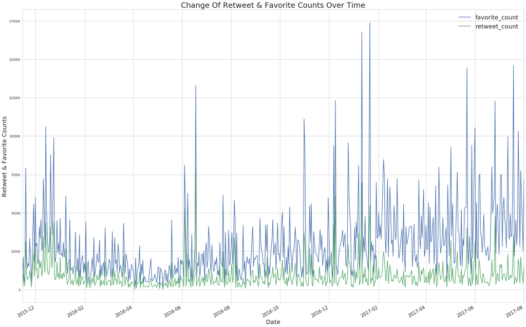

```python
df_count[['favorite_count', 'retweet_count']].plot()
plt.title('Change Of Retweet & Favorite Counts Over Time', fontsize=25)
plt.xticks(size = 15)
plt.xlabel('Date', fontsize=20)
plt.ylabel('Retweet & Favorite Counts', fontsize=20);
plt.rc('figure', figsize=(30,20))
plt.legend(fontsize=20) # legend
```

##### Results:

There is a small increase especially in the favorite_count, which shows so much more values than the retweet_count. And this makes sense, many users might have nothing to say other than i like this.

Although the change in retweet_count is smaller than the one in favorite_count, it's still correlated with it.

I notice especially higher peaks in both counts in two periods during the year, around end/start of year, and around mid of year. it might be because these two periods are the most active during the year, after holidays and the start of summer

### Dog Breed

I would like to see what breed has the highest prediction, and what is the average rate for the highest predictions

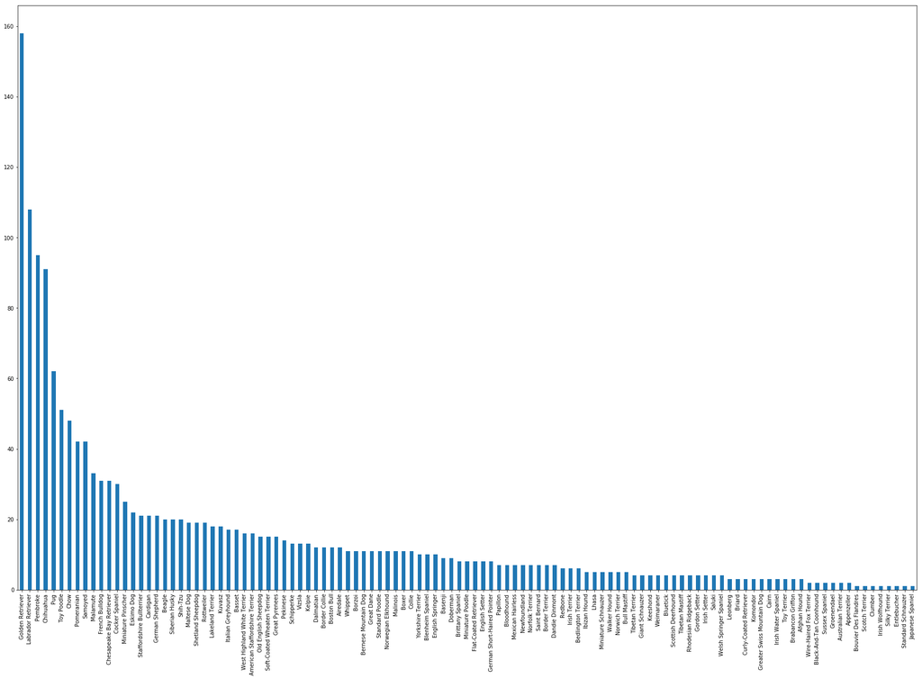

```python
WeRateDogs[WeRateDogs['breed'] != "Not Sure"]['breed'].value_counts().plot(kind = 'bar')
```

This is along list, i'll limit to the breeds with the 15 counts and above. This will make my plot more readable.

```python
#excluding rows that has no dog breed and also excluding breeds with less or 15 occurrence.
breed_counts = WeRateDogs[WeRateDogs['breed'] != "Not Sure"]['breed'].value_counts()[WeRateDogs['breed'].value_counts() > 15]
```

[figure not shown]

```python
breed_counts.plot(kind = 'bar')
plt.title('Highest Prediction for Dogs Breed (Top numbers)', fontsize=25)
plt.xticks(size = 15)
plt.xlabel('Dogs Breed', fontsize=20)
plt.ylabel('Prediction Count (only > 25)', fontsize=20);
plt.rc('figure', figsize=(30,20))
```

```python
print(WeRateDogs[WeRateDogs['breed'] == "Golden Retriever"]['rating_numerator'].mean())
print(WeRateDogs[WeRateDogs['breed'] == "Labrador Retriever"]['rating_numerator'].mean())
print(WeRateDogs[WeRateDogs['breed'] == "Pembroke"]['rating_numerator'].mean())
print(WeRateDogs[WeRateDogs['breed'] == "Chihuahua"]['rating_numerator'].mean())
```

```
12.9651898734
13.6111111111
11.3684210526
10.4835164835
```

### Dogs Staging

What is the most popular dog stage? What is the highest rate for every dog stage?

```python
#dogs_staging distribution
WeRateDogs['dogs_staging'].value_counts()
```

```
unknown    1641
pupper     223
doggo      72
floofer    29
puppo      28
blep       1
Name: dogs_staging, dtype: int64
```

```python
#Checking the five numbers for dogs rating percentage by dogs staging
WeRateDogs.groupby('dogs_staging')['rating_percent'].describe()
```

| dogs_staging | count | mean | std | min | 25% | 50% | 75% | max |
| --- | --- | --- | --- | --- | --- | --- | --- | --- |
| blep | 1.0 | 1.200000 | NaN | 1.2 | 1.2 | 1.20 | 1.2 | 1.2 |
| doggo | 72.0 | 1.163889 | 0.163849 | 0.5 | 1.1 | 1.20 | 1.3 | 1.4 |
| floofer | 29.0 | 0.889655 | 0.396723 | 0.2 | 0.6 | 1.10 | 1.2 | 1.3 |
| pupper | 223.0 | 1.056170 | 0.185174 | 0.3 | 1.0 | 1.10 | 1.2 | 1.4 |
| puppo | 28.0 | 1.214286 | 0.120844 | 0.9 | 1.2 | 1.25 | 1.3 | 1.4 |
| unknown | 1641.0 | 1.181498 | 4.478873 | 0.0 | 1.0 | 1.10 | 1.2 | 177.6 |

```python
# difference in rating count between doggo and puppo
72 - 28, 223 - 28
```

```
(44, 195)
```

##### Results:

So although puppo has 44 less rating counts than doggo, and 195 less than pupper It still has higher rating average than both. I wonder why

### Dogs Rates

How is dogs rates changed overtime? What is the most frequent rate (score)?

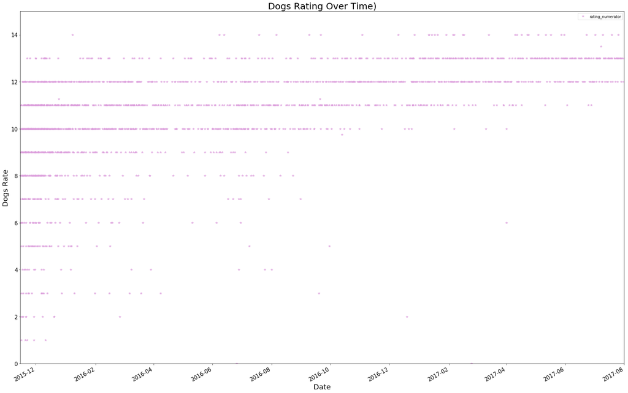

```python
WeRateDogs.plot(y ='rating_numerator', ylim=[0,15], style = '*', color = 'plum', alpha = .7)
plt.title('Dogs Rating Over Time)', fontsize=25)
plt.xticks(size = 15)
plt.yticks(size = 15)
plt.xlabel('Date', fontsize=20)
plt.ylabel('Dogs Rate', fontsize=20);
plt.rc('figure', figsize=(30,20))
```

```
[Text(0,0.5,'Dogs rating'),
 Text(0.5,0,'Count'),
 Text(0.5,1,'Counts of Dogs Rating')]
```

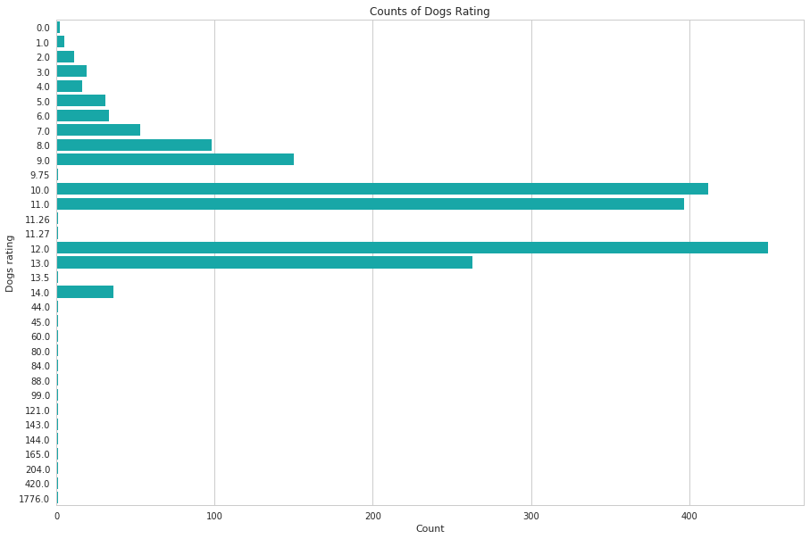

```python
#sns.countplot(y="rating_numerator", hue="dogs_staging", data=WeRateDogs, palette="Greens_d");
sns.set(style="whitegrid")
f, ax = plt.subplots(figsize=(15, 10))
sns.countplot(y="rating_numerator", data=WeRateDogs, color="c")
ax.set(ylabel="Dogs rating",
       xlabel="Count", title = "Counts of Dogs Rating")
```

##### Results:

Rates level is increasing overtime, there are certainly more enthusiasm and participation. We can barely see any rates below 10 after 2016-10

12 is the most frequent dog rate (more than 400), 10 comes next, then 11, then 13. Other rates counts are 150 and less. i think this makes sense, with the unusual and unique rating system that many users are enjoying, people still tend to stay close to 10 in their ratings. in my opinion, this is a human mentality.

## Conclusion

**Limitations:**

- The dogs stages were extracted from the text, so it completely depend on the tweet having one of the stages clearly mentioned.
- The Rates were also extracted from the tweet text, and while i was able to extract numbers for all tweets, they are not all accurate, the reason is that many tweets had more than rate for multiple dogs
- Not all tweets had images, so i had to exclude those ones.
- The dogs breed prediction wasn't correct for all tweets, this resulted in some unidentified breeds.
- The unique rating system resulted on many outliers in the rates

**With the limitation in the data i had, and based on my analysis, these are my "TENTATIVE" findings:**

Overall, the data shows an increase in rating scores overtime. We can barely see any rates below 10 after 2016-10. the most frequent rate (score) is 12, then comes 10.

puppo has higher rating average (12.1) among other dog stages. doggo (11.6) and pupper (10.6) come next. However, pupper has the most rating count among all.

There are high peaks in both counts in two periods during the year, around end/start of year, and around mid of year. it might be because these two periods are the most active during the year, after holidays and the start of summer